# *Introduction*

Since Jan. 1, 2015, [The Washington Post](https://www.washingtonpost.com/) has been compiling a database of every fatal shooting in the US by a police officer in the line of duty.

[figure not shown]

While there are many challenges regarding data collection and reporting, The Washington Post has been tracking more than a dozen details about each killing. This includes the race, age and gender of the deceased, whether the person was armed, and whether the victim was experiencing a mental-health crisis. The Washington Post has gathered this supplemental information from law enforcement websites, local new reports, social media, and by monitoring independent databases such as "Killed by police" and "Fatal Encounters". The Post has also conducted additional reporting in many cases.

There are 4 additional datasets: US census data on poverty rate, high school graduation rate, median household income, and racial demographics. [Source of census data](https://factfinder.census.gov/faces/nav/jsf/pages/community_facts.xhtml).

### Upgrade Plotly

Run the cell below if you are working with Google Colab

```python
# %pip install --upgrade plotly
```

## *Import Statements*

```python
import numpy as np
import pandas as pd
import plotly.express as px
import matplotlib.pyplot as plt
import seaborn as sns

# This might be helpful:
from collections import Counter
```

## *Notebook Presentation*

```python
pd.options.display.float_format = '{:,.2f}'.format
```

## *Load the Data*

#### *Make file retrieval process more robust w/`os` stuff:*

```python
import os
```

```python
curr_dir = os.getcwd()
data_dir = os.path.join(curr_dir, 'data')

data_dir
```

```
'e:\\nowGitRepos\\dataLawUS\\data'
```

```python
enc = 'windows-1252'

hh_income_csv_path = os.path.join(data_dir, "Median_Household_Income_2015.csv")
df_hh_income = pd.read_csv(hh_income_csv_path, encoding=enc)

pct_poverty_csv_path = os.path.join(data_dir, "Pct_People_Below_Poverty_Level.csv")
df_pct_poverty = pd.read_csv(pct_poverty_csv_path, encoding=enc)

pct_completed_hs_csv_path = os.path.join(data_dir, "Pct_Over_25_Completed_High_School.csv")
df_pct_completed_hs = pd.read_csv(pct_completed_hs_csv_path, encoding=enc)

share_race_city_csv_path = os.path.join(data_dir, "Share_of_Race_By_City.csv")
df_share_race_city = pd.read_csv(share_race_city_csv_path, encoding=enc)

fatalities_csv_path = os.path.join(data_dir, "Deaths_by_Police_US.csv")
df_fatalities = pd.read_csv(fatalities_csv_path, encoding=enc)
```

# *Preliminary Data Exploration*

- What is the shape of the DataFrames?

```python
print(f"`df_hh_income` shape: {df_hh_income.shape}")
print(f"`df_pct_poverty` shape: {df_pct_poverty.shape}")
print(f"`df_pct_completed_hs` shape: {df_pct_completed_hs.shape}")
print(f"`df_share_race_city` shape: {df_share_race_city.shape}")
print(f"`df_fatalities` shape: {df_fatalities.shape}")
```

```
`df_hh_income` shape: (29322, 3)
`df_pct_poverty` shape: (29329, 3)
`df_pct_completed_hs` shape: (29329, 3)
`df_share_race_city` shape: (29268, 7)
`df_fatalities` shape: (2535, 14)
```

- How many rows and columns do they have?

```python
df_hh_income_columns, df_hh_income_rows = df_hh_income.shape
print(f"df_hh_income cols: {df_hh_income_columns}")
print(f"df_hh_income rows: {df_hh_income_rows}\n")

df_pct_poverty_columns, df_pct_poverty_rows = df_pct_poverty.shape
print(f"df_pct_poverty cols: {df_pct_poverty_columns}")
print(f"df_pct_poverty rows: {df_pct_poverty_rows}\n")

df_pct_completed_hs_columns, df_pct_completed_hs_rows = df_pct_completed_hs.shape
print(f"df_pct_completed_hs cols: {df_pct_completed_hs_columns}")
print(f"df_pct_completed_hs rows: {df_pct_completed_hs_rows}\n")

df_share_race_city_columns, df_share_race_city_rows = df_share_race_city.shape
print(f"df_share_race_city cols: {df_share_race_city_columns}")
print(f"df_share_race_city rows: {df_share_race_city_rows}\n")

df_fatalities_columns, df_fatalities_rows = df_fatalities.shape
print(f"df_fatalities cols: {df_fatalities_columns}")
print(f"df_fatalities rows: {df_fatalities_rows}\n")
```

```
df_hh_income cols: 29322
df_hh_income rows: 3

df_pct_poverty cols: 29329
df_pct_poverty rows: 3

df_pct_completed_hs cols: 29329
df_pct_completed_hs rows: 3

df_share_race_city cols: 29268
df_share_race_city rows: 7

df_fatalities cols: 2535
df_fatalities rows: 14
```

#### *Analysis:*

The first four DFs have similar number of rows.

The second and third DFs have the exact same number of rows.

The first three have the same number of columns.

The last has many fewer rows, but more columns.

- What are the column names?

```python
def format_col_names(dataframe):
    col_list = dataframe.columns
    col_name_str = ", ".join(col_list)
    return col_name_str
```

```python
df_hh_income_cols = format_col_names(df_hh_income)
print(f"`df_hh_income` col names: {df_hh_income_cols}\n")

df_pct_poverty_cols = format_col_names(df_pct_poverty)
print(f"`df_pct_poverty` col names: {df_pct_poverty_cols}\n")

df_pct_completed_hs_cols = format_col_names(df_pct_completed_hs)
print(f"`df_pct_completed_hs` col names: {df_pct_completed_hs_cols}\n")

df_share_race_city_cols = format_col_names(df_share_race_city)
print(f"`df_share_race_city` col names: {df_share_race_city_cols}\n")

df_fatalities_cols = format_col_names(df_fatalities)
print(f"`df_fatalities` col names: {df_fatalities_cols}\n")
```

```
`df_hh_income` col names: Geographic Area, City, Median Income

`df_pct_poverty` col names: Geographic Area, City, poverty_rate

`df_pct_completed_hs` col names: Geographic Area, City, percent_completed_hs

`df_share_race_city` col names: Geographic area, City, share_white, share_black, share_native_american, share_asian, share_hispanic

`df_fatalities` col names: id, name, date, manner_of_death, armed, age, gender, race, city, state, signs_of_mental_illness, threat_level, flee, body_camera
```

- Are there any NaN values or duplicates?

```python
print(f"`NaN` info for `df_hh_income`: {df_hh_income.isna().sum()}\n")
print(f"Duplicate # for `df_hh_income`: {df_hh_income.duplicated().sum()}\n")
```

```
`NaN` info for `df_hh_income`: Geographic Area     0
City                0
Median Income      51
dtype: int64

Duplicate # for `df_hh_income`: 0
```

```python
print(f"`NaN` info for `df_pct_poverty`: {df_pct_poverty.isna().sum()}\n")
print(f"Duplicate # for `df_pct_poverty`: {df_pct_poverty.duplicated().sum()}\n")
```

```
`NaN` info for `df_pct_poverty`: Geographic Area    0
City               0
poverty_rate       0
dtype: int64

Duplicate # for `df_pct_poverty`: 0
```

```python
print(f"`NaN` info for `df_pct_completed_hs`: {df_pct_completed_hs.isna().sum()}\n")
print(f"Duplicate # for `df_pct_completed_hs`: {df_pct_completed_hs.duplicated().sum()}\n")
```

```
`NaN` info for `df_pct_completed_hs`: Geographic Area         0
City                    0
percent_completed_hs    0
dtype: int64

Duplicate # for `df_pct_completed_hs`: 0
```

```python
print(f"`NaN` info for `df_share_race_city`: {df_share_race_city.isna().sum()}\n")
print(f"Duplicate # for `df_share_race_city`: {df_share_race_city.duplicated().sum()}\n")
```

```
`NaN` info for `df_share_race_city`: Geographic area          0
City                     0
share_white              0
share_black              0
share_native_american    0
share_asian              0
share_hispanic           0
dtype: int64

Duplicate # for `df_share_race_city`: 0
```

```python
print(f"`NaN` info for `df_fatalities`: {df_fatalities.isna().sum()}\n")
print(f"Duplicate # for `df_fatalities`: {df_fatalities.duplicated().sum()}\n")
```

```
`NaN` info for `df_fatalities`: id                           0
name                         0
date                         0
manner_of_death              0
armed                        9
age                         77
gender                       0
race                       195
city                         0
state                        0
signs_of_mental_illness      0
threat_level                 0
flee                        65
body_camera                  0
dtype: int64

Duplicate # for `df_fatalities`: 0
```

#### *Analysis:*

df_hh_income and df_fatalities have NaN issues.

None of the DFs have duplicates.

## *Data Cleaning - Check for Missing Values and Duplicates*

Consider how to deal with the NaN values. Perhaps substituting 0 is appropriate.

```python
# Before fixing NaNs:
df_hh_income.isna().sum()
```

```
Geographic Area     0
City                0
Median Income      51
dtype: int64
```

```python
df_hh_income['Median Income'] = df_hh_income['Median Income'].fillna(0)
```

```python
# After fixing NaNs:
df_hh_income.isna().sum()
```

```
Geographic Area    0
City               0
Median Income      0
dtype: int64
```

```python
# Before fixing NaNs:
df_fatalities.isna().sum()
```

```
id                           0
name                         0
date                         0
manner_of_death              0
armed                        9
age                         77
gender                       0
race                       195
city                         0
state                        0
signs_of_mental_illness      0
threat_level                 0
flee                        65
body_camera                  0
dtype: int64
```

```python
df_fatalities['armed'] = df_fatalities['armed'].fillna(0)
df_fatalities['age'] = df_fatalities['age'].fillna(0)
df_fatalities['race'] = df_fatalities['race'].fillna(0)
df_fatalities['flee'] = df_fatalities['flee'].fillna(0)
```

```python
# After fixing NaNs:
df_fatalities.isna().sum()
```

```
id                         0
name                       0
date                       0
manner_of_death            0
armed                      0
age                        0
gender                     0
race                       0
city                       0
state                      0
signs_of_mental_illness    0
threat_level               0
flee                       0
body_camera                0
dtype: int64
```

#### *Analysis:*

All `NaN`s handled.

No duplicates to be handled.

# *Chart the Poverty Rate in each US State*

Create a bar chart that ranks the poverty rate from highest to lowest by US state. Which state has the highest poverty rate? Which state has the lowest poverty rate? Bar Plot

```python
# df_hh_income
# df_pct_poverty
# df_pct_completed_hs
# df_share_race_city
# df_fatalities
```

##### *Check data types for column `poverty_rate`:*

```python
df_pct_poverty.dtypes
```

```
Geographic Area    object
City               object
poverty_rate       object
dtype: object
```

##### *Check all strings are numbers:*

```python
# for i in df_pct_poverty.poverty_rate:
#     print(i)
```

##### *Some values are `-`, let's replace them with `0`:*

```python
df_pct_poverty["poverty_rate"] = df_pct_poverty["poverty_rate"].replace("-", "0")
```

##### *Convert that column from str/object to numeric/int:*

```python
df_pct_poverty["poverty_rate"] = pd.to_numeric(df_pct_poverty["poverty_rate"])
```

##### *Remove rows w/0 (no data):*

```python
df_pct_poverty = df_pct_poverty[df_pct_poverty["poverty_rate"] != 0]
```

##### *Two ways to aggregate data:*

```python
df_pov_state = df_pct_poverty.groupby("Geographic Area")["poverty_rate"].mean().reset_index()

# Or:
# df_pov_state = df_pct_poverty.groupby("Geographic Area").agg({"poverty_rate": 'mean'}).reset_index()
```

##### *Sort and reset indices:*

```python
df_pov_state.sort_values(by="poverty_rate", inplace=True, ascending=False)
df_pov_state.reset_index(inplace=True, drop=True)
```

##### *Verify the new DF:*

```python
# df_pov_state
```

##### *Colors I like for a white background:*

```python
seaborn_palettes = ['deep', 'muted', 'pastel', 'bright', 'dark', 'colorblind']
```

```python
from matplotlib import colormaps
all_palettes = list(colormaps) + seaborn_palettes
```

```python
pov_states = df_pov_state["Geographic Area"]
pov_rate = df_pov_state["poverty_rate"]
```

```python
from random import choice, choices
```

##### *w/Seaborn:*

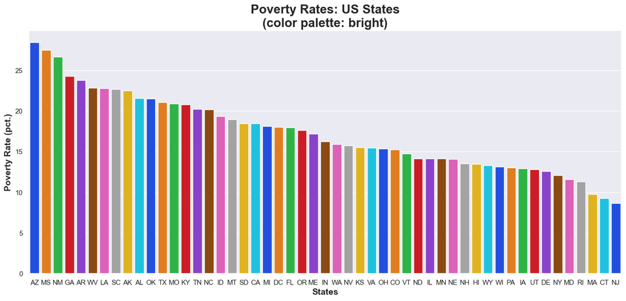

```python
# Initialize MatPlotLib figure
fig, ax = plt.subplots(figsize=(17, 7))

palette = choice(seaborn_palettes)

# Plot the months/counts:
# sns.barplot(x=pov_states, y=pov_rate, hue=pov_states, palette=palette, legend='auto')
sns.barplot(
    df_pov_state,
    x="Geographic Area",
    y="poverty_rate",
    hue="Geographic Area",
    palette=palette,
)

plt.xlabel("States", size=14, weight='bold')
plt.ylabel("Poverty Rate (pct.)", size=14, weight='bold')

plt.title(f"Poverty Rates: US States\n(color palette: {palette})",
          size=20,
          weight='bold')

plt.show()
```

```python
colors = ["blue",
          "navy",
          "peru",
          "black",
          "brown",
          "green",
          "olive",
          "indigo",
          "maroon",
          "purple",
          "sienna",
          "crimson",
          "darkred",
          "dimgray",
          "darkblue",
          "darkcyan",
          "deeppink",
          "seagreen",
          "chocolate",
          "darkgreen",
          "darkkhaki",
          "firebrick",
          "goldenrod",
          "limegreen",
          "olivedrab",
          "palegreen",
          "rosybrown",
          "royalblue",
          "slateblue",
          "steelblue",
          "darkorange",
          "darkorchid",
          "darksalmon",
          "darkviolet",
          "dodgerblue",
          "lightgreen",
          "mediumblue",
          "sandybrown",
          "darkmagenta",
          "forestgreen",
          "greenyellow",
          "saddlebrown",
          "springgreen",
          "yellowgreen",
          "darkseagreen",
          "midnightblue",
          "darkgoldenrod",
          "darkslateblue",
          "darkslategray",
          "darkslategrey",
          "darkturquoise",
          "rebeccapurple",
          "cornflowerblue",
          "darkolivegreen",
          "mediumseagreen",
          "mediumslateblue",
          "mediumspringgreen"]
```

```python
bar_colors = choices(colors, k=len(df_pov_state))
```

```python
# Create labels for legend:
state_rate = zip(pov_states, pov_rate)
labels_state_rate = [f"{state}: {round(rate, 2)}%" for state, rate in state_rate]
```

##### *w/Matplotlib and descriptive legend:*

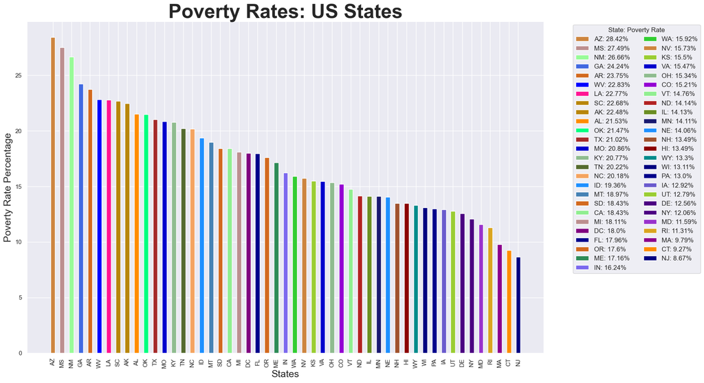

```python
fig, ax = plt.subplots(figsize=(17, 11))

ax.bar(x=pov_states,
       height=pov_rate,
       label=labels_state_rate,
       color=bar_colors,
       width=0.5)

ax.set_title("Poverty Rates: US States", fontsize=36, weight='bold')
ax.set_xlabel("States", fontsize=18)
ax.set_ylabel("Poverty Rate Percentage", fontsize=18)

plt.legend(ncol=2,
           title="State: Poverty Rate",
           fontsize='medium',
           bbox_to_anchor=(1.05, 1))

plt.xticks(rotation=90)

plt.show()
```

#### *Analysis:*

```python
df_pov_state.describe()
```

|  | poverty_rate |
| --- | --- |
| count | 51.00 |
| mean | 17.24 |
| std | 4.74 |
| min | 8.67 |
| 25% | 13.49 |
| 50% | 16.24 |
| 75% | 20.82 |
| max | 28.42 |

Which state has the highest poverty rate?

Which state has the lowest poverty rate?

# *Chart the High School Graduation Rate by US State*

Show the High School Graduation Rate in ascending order of US States.

Which state has the lowest high school graduation rate?

Which state has the highest?

### *Do the exact same as above:*

#### *Clean/aggregate new dataframe:*

```python
df_pct_completed_hs.columns
```

```
Index(['Geographic Area', 'City', 'percent_completed_hs'], dtype='object')
```

```python
df_pct_completed_hs.dtypes
```

```
Geographic Area         object
City                    object
percent_completed_hs    object
dtype: object
```

```python
for i in df_pct_completed_hs.percent_completed_hs:
    print(i)
```

```python
df_pct_completed_hs["percent_completed_hs"] = df_pct_completed_hs["percent_completed_hs"].replace("-", "0")
```

```python
df_pct_completed_hs["percent_completed_hs"] = pd.to_numeric(df_pct_completed_hs["percent_completed_hs"])
```

```python
df_pct_completed_hs = df_pct_completed_hs[df_pct_completed_hs["percent_completed_hs"] != 0]
```

```python
# df_pct_completed_hs
```

```python
df_hs_state = df_pct_completed_hs.groupby("Geographic Area")["percent_completed_hs"].mean().reset_index()

# Or:
# df_hs_state = df_pct_completed_hs.groupby("Geographic Area").agg({"percent_completed_hs": 'mean'}).reset_index()
```

```python
# df_hs_state
# df_pct_completed_hs
# percent_completed_hs
```

```python
df_hs_state.sort_values(by="percent_completed_hs", inplace=True, ascending=True)
df_hs_state.reset_index(inplace=True, drop=True)
```

```python
# df_hs_state
```

#### *Plot:*

```python
colors = ["black",
          "blue",
          "brown",
          "chocolate",
          "cornflowerblue",
          "crimson",
          "darkblue",
          "darkcyan",
          "darkgoldenrod",
          "darkgreen",
          "darkkhaki",
          "darkmagenta",
          "darkolivegreen",
          "darkorange",
          "darkorchid",
          "darkred",
          "darksalmon",
          "darkseagreen",
          "darkslateblue",
          "darkslategray",
          "darkslategrey",
          "darkturquoise",
          "darkviolet",
          "deeppink",
          "dimgray",
          "dodgerblue",
          "firebrick",
          "forestgreen",
          "goldenrod",
          "green",
          "greenyellow",
          "indigo",
          "lightgreen",
          "limegreen",
          "maroon",
          "mediumblue",
          "mediumseagreen",
          "mediumslateblue",
          "mediumspringgreen",
          "midnightblue",
          "navy",
          "olive",
          "olivedrab",
          "palegreen",
          "peru",
          "purple",
          "rebeccapurple",
          "rosybrown",
          "royalblue",
          "saddlebrown",
          "sandybrown",
          "seagreen",
          "sienna",
          "slateblue",
          "springgreen",
          "steelblue",
          "yellowgreen"]
```

```python
states = df_hs_state["Geographic Area"]

grad = df_hs_state["percent_completed_hs"]

# Create labels for legend:
state_grad = zip(states, grad)
labels_state_grad = [f"{state}: {round(grad, 2)}%" for state, grad in state_grad]
```

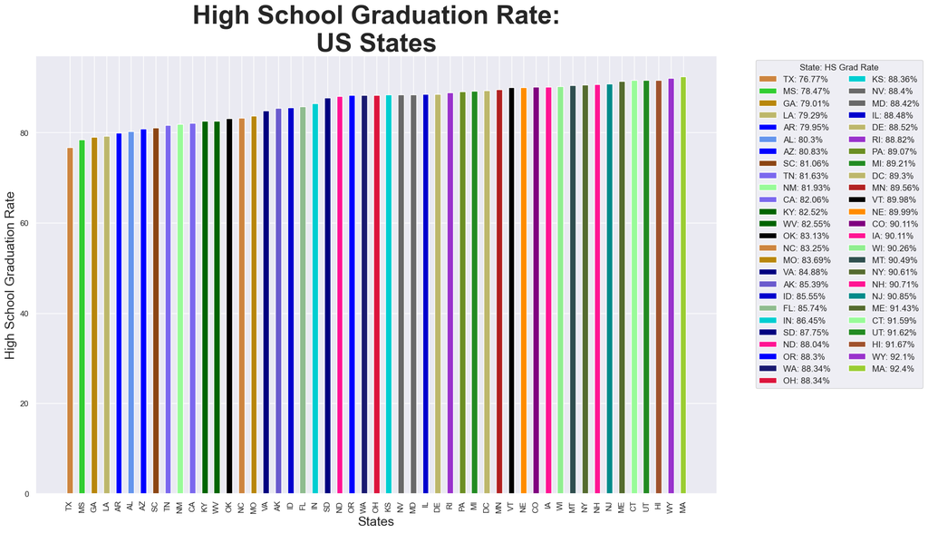

```python
fig, ax = plt.subplots(figsize=(17, 11))

bar_colors = choices(colors, k=len(df_hs_state))

ax.bar(x=states,
       height=grad,
       label=labels_state_grad,
       color=bar_colors,
       width=0.5)

ax.set_title("High School Graduation Rate:\nUS States", fontsize=36, weight='bold')
ax.set_xlabel("States", fontsize=18)
ax.set_ylabel("High School Graduation Rate", fontsize=18)

plt.legend(ncol=2,
           title="State: HS Grad Rate",
           fontsize='medium',
           bbox_to_anchor=(1.05, 1))

plt.xticks(rotation=90)

plt.show()
```

```python
df_pov_state.describe()
```

|  | poverty_rate |
| --- | --- |
| count | 51.00 |
| mean | 17.24 |
| std | 4.74 |
| min | 8.67 |
| 25% | 13.49 |
| 50% | 16.24 |
| 75% | 20.82 |
| max | 28.42 |

#### *Analysis:*

Which state has the lowest high school graduation rate?

- Texas (TX): $76.77\%$

Which state has the highest?

- Massachusetts (MA): $92.4\%$

Middle:

- Ohio (OH): $88.34\%$

# *Visualise the Relationship between Poverty Rates and High School Graduation Rates*

#### Create a line chart with two y-axes to show if the ratio of poverty and high school graduation move together.

#### *Create DF with poverty and high school data merged on State names:*

```python
df_state_hs_poverty = df_hs_state.merge(df_pov_state, on='Geographic Area')
```

```python
df_state_hs_poverty
```

|  | Geographic Area | percent_completed_hs | poverty_rate |
| --- | --- | --- | --- |
| 0 | TX | 76.77 | 21.02 |
| 1 | MS | 78.47 | 27.49 |
| 2 | GA | 79.01 | 24.24 |
| 3 | LA | 79.29 | 22.77 |
| 4 | AR | 79.95 | 23.75 |
| 5 | AL | 80.30 | 21.53 |
| 6 | AZ | 80.83 | 28.42 |
| 7 | SC | 81.06 | 22.68 |
| 8 | TN | 81.63 | 20.22 |
| 9 | NM | 81.93 | 26.66 |
| 10 | CA | 82.06 | 18.43 |
| 11 | KY | 82.52 | 20.77 |
| 12 | WV | 82.55 | 22.83 |
| 13 | OK | 83.13 | 21.47 |
| 14 | NC | 83.25 | 20.18 |
| 15 | MO | 83.69 | 20.86 |
| 16 | VA | 84.88 | 15.47 |
| 17 | AK | 85.39 | 22.48 |
| 18 | ID | 85.55 | 19.36 |
| 19 | FL | 85.74 | 17.96 |
| 20 | IN | 86.45 | 16.24 |
| 21 | SD | 87.75 | 18.43 |
| 22 | ND | 88.04 | 14.14 |
| 23 | OR | 88.30 | 17.60 |
| 24 | WA | 88.34 | 15.92 |
| 25 | OH | 88.34 | 15.34 |
| 26 | KS | 88.36 | 15.50 |
| 27 | NV | 88.40 | 15.73 |
| 28 | MD | 88.42 | 11.59 |
| 29 | IL | 88.48 | 14.13 |
| 30 | DE | 88.52 | 12.56 |
| 31 | RI | 88.82 | 11.31 |
| 32 | PA | 89.07 | 13.00 |
| 33 | MI | 89.21 | 18.11 |
| 34 | DC | 89.30 | 18.00 |
| 35 | MN | 89.56 | 14.11 |
| 36 | VT | 89.98 | 14.76 |
| 37 | NE | 89.99 | 14.06 |
| 38 | CO | 90.11 | 15.21 |
| 39 | IA | 90.11 | 12.92 |
| 40 | WI | 90.26 | 13.11 |
| 41 | MT | 90.49 | 18.97 |
| 42 | NY | 90.61 | 12.06 |
| 43 | NH | 90.71 | 13.49 |
| 44 | NJ | 90.85 | 8.67 |
| 45 | ME | 91.43 | 17.16 |
| 46 | CT | 91.59 | 9.27 |
| 47 | UT | 91.62 | 12.79 |
| 48 | HI | 91.67 | 13.49 |
| 49 | WY | 92.10 | 13.30 |
| 50 | MA | 92.40 | 9.79 |

#### *Inspect date:*

```python
for i in range(len(df_state_hs_poverty)):
    state = df_state_hs_poverty['Geographic Area'][i]
    print(state)
    state_grad_rate = df_state_hs_poverty['percent_completed_hs'][i]
    print(state_grad_rate)
    state_pov_rate = df_state_hs_poverty['poverty_rate'][i]
    print(state_pov_rate)
```

#### *Create column for state names for clarity on plot:*

```python
state_dict = {"TX": "Texas", "MS": "Mississippi", "GA": "Georgia", "LA": "Louisiana", "AR": "Arkansas", "AL": "Alabama", "AZ": "Arizona", "SC": "South Carolina", "TN": "Tennessee", "NM": "New Mexico", "CA": "California", "KY": "Kentucky", "WV": "West Virginia", "OK": "Oklahoma", "NC": "North Carolina", "MO": "Missouri", "VA": "Virginia", "AK": "Alaska", "ID": "Idaho", "FL": "Florida", "IN": "Indiana", "SD": "South Dakota", "ND": "North Dakota", "OR": "Oregon", "WA": "Washington", "OH": "Ohio", "KS": "Kansas", "NV": "Nevada", "MD": "Maryland", "IL": "Illinois", "DE": "Delaware", "RI": "Rhode Island", "PA": "Pennsylvania", "MI": "Michigan", "DC": "District of Columbia", "MN": "Minnesota", "VT": "Vermont", "NE": "Nebraska", "CO": "Colorado", "IA": "Iowa", "WI": "Wisconsin", "MT": "Montana", "NY": "New York", "NH": "New Hampshire", "NJ": "New Jersey", "ME": "Maine", "CT": "Connecticut", "UT": "Utah", "HI": "Hawaii", "WY": "Wyoming", "MA": "Massachusetts"}

state_names= np.array([state_dict.get(i) for i in df_state_hs_poverty['Geographic Area']],
                      dtype='object')

df_state_hs_poverty['State_Names'] = state_names
```

#### *Do the thing:*

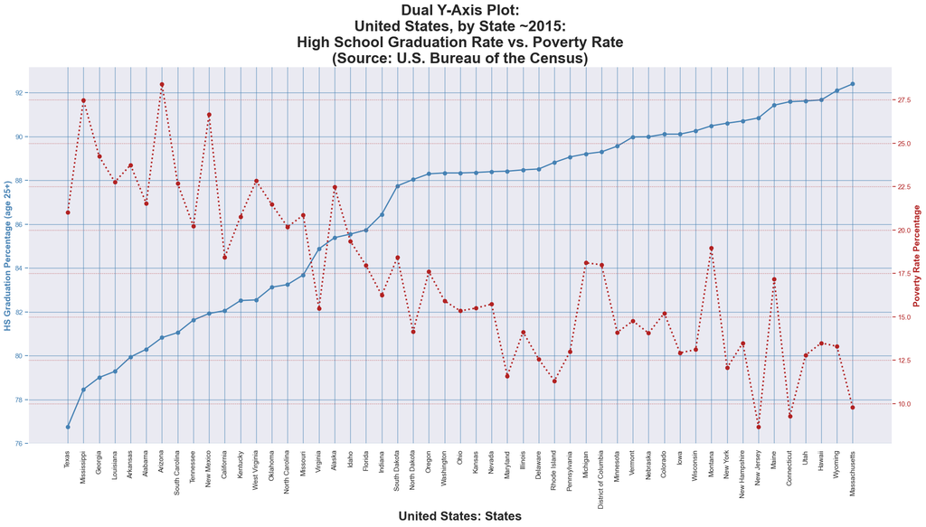

```python
# Create axes:
fig, ax1 = plt.subplots(figsize=(25, 11))
ax2 = ax1.twinx()

# Extract data from DataFrame, using state names instead of abbreviations:
states = df_state_hs_poverty['State_Names']
state_grad_rates = np.round(df_state_hs_poverty['percent_completed_hs'], 2)
state_pov_rates = np.round(df_state_hs_poverty['poverty_rate'], 2)

# Axes colors (find good complements):
ax1_color = 'steelblue'
ax2_color = 'firebrick'

# Plot left y-axis, Graduation Rate:
ax1.plot(states,
         state_grad_rates,
         label=f"{states}: {state_grad_rates}",
         linewidth=2,
         linestyle='-',
         marker='o',
         color=ax1_color)

# Plot right y-axis, Poverty Rate:
ax2.plot(states,
         state_pov_rates,
         label=f"{states}: {state_pov_rates}",
         linewidth=2.5,
         linestyle=':',
         marker='o',
         color=ax2_color)

# Make a title:
title = "Dual Y-Axis Plot:\n"
title += "United States, by State ~2015:\n"
title += "High School Graduation Rate vs. Poverty Rate\n"
title += "(Source: U.S. Bureau of the Census)"
ax1.set_title(title, fontsize=24, weight='bold')


# Make x-axis label:
ax1.set_xlabel("United States: States", fontsize=20, weight='bold')

# Make y-axes labels:
ax1.set_ylabel("HS Graduation Percentage (age 25+)",
                fontsize=14,
                weight='bold')

ax2.set_ylabel("Poverty Rate Percentage",
               fontsize=14,
               weight='bold')

# Customize each axes grid for ease of plot visualization:
ax1.grid(color=ax1_color, linestyle='-', alpha=0.7)
ax1.yaxis.label.set_color(ax1_color)
ax1.tick_params(axis='y', colors=ax1_color)

ax2.grid(color=ax2_color, linestyle=':', alpha=0.7)
ax2.yaxis.label.set_color(ax2_color)
ax2.tick_params(axis='y', colors=ax2_color)

# Rotate x-axis tick labels:
ax1.set_xticks(states)
ax1.set_xticklabels(states, rotation=90)

# Show the thing:
plt.show()
```

#### *Analysis:*

There is a general trend when viewing the Graduation and Poverty data in this dual plot:

- The upward graduation rate trend is in stark contrast to a trend of falling poverty rates.
- My conclusion is that states with higher high school graduation rates tend to have lower poverty.

There are specific exceptions to this contrasting trend, but the general pattern is obvious.

#### Now use a Seaborn .jointplot() with a Kernel Density Estimate (KDE) and/or scatter plot to visualise the same relationship

```python
df_state_hs_poverty
```

|  | Geographic Area | percent_completed_hs | poverty_rate | State_Names |
| --- | --- | --- | --- | --- |
| 0 | TX | 76.77 | 21.02 | Texas |
| 1 | MS | 78.47 | 27.49 | Mississippi |
| 2 | GA | 79.01 | 24.24 | Georgia |
| 3 | LA | 79.29 | 22.77 | Louisiana |
| 4 | AR | 79.95 | 23.75 | Arkansas |
| 5 | AL | 80.30 | 21.53 | Alabama |
| 6 | AZ | 80.83 | 28.42 | Arizona |
| 7 | SC | 81.06 | 22.68 | South Carolina |
| 8 | TN | 81.63 | 20.22 | Tennessee |
| 9 | NM | 81.93 | 26.66 | New Mexico |
| 10 | CA | 82.06 | 18.43 | California |
| 11 | KY | 82.52 | 20.77 | Kentucky |
| 12 | WV | 82.55 | 22.83 | West Virginia |
| 13 | OK | 83.13 | 21.47 | Oklahoma |
| 14 | NC | 83.25 | 20.18 | North Carolina |
| 15 | MO | 83.69 | 20.86 | Missouri |
| 16 | VA | 84.88 | 15.47 | Virginia |
| 17 | AK | 85.39 | 22.48 | Alaska |
| 18 | ID | 85.55 | 19.36 | Idaho |
| 19 | FL | 85.74 | 17.96 | Florida |
| 20 | IN | 86.45 | 16.24 | Indiana |
| 21 | SD | 87.75 | 18.43 | South Dakota |
| 22 | ND | 88.04 | 14.14 | North Dakota |
| 23 | OR | 88.30 | 17.60 | Oregon |
| 24 | WA | 88.34 | 15.92 | Washington |
| 25 | OH | 88.34 | 15.34 | Ohio |
| 26 | KS | 88.36 | 15.50 | Kansas |
| 27 | NV | 88.40 | 15.73 | Nevada |
| 28 | MD | 88.42 | 11.59 | Maryland |
| 29 | IL | 88.48 | 14.13 | Illinois |
| 30 | DE | 88.52 | 12.56 | Delaware |
| 31 | RI | 88.82 | 11.31 | Rhode Island |
| 32 | PA | 89.07 | 13.00 | Pennsylvania |
| 33 | MI | 89.21 | 18.11 | Michigan |
| 34 | DC | 89.30 | 18.00 | District of Columbia |
| 35 | MN | 89.56 | 14.11 | Minnesota |
| 36 | VT | 89.98 | 14.76 | Vermont |
| 37 | NE | 89.99 | 14.06 | Nebraska |
| 38 | CO | 90.11 | 15.21 | Colorado |
| 39 | IA | 90.11 | 12.92 | Iowa |
| 40 | WI | 90.26 | 13.11 | Wisconsin |
| 41 | MT | 90.49 | 18.97 | Montana |
| 42 | NY | 90.61 | 12.06 | New York |
| 43 | NH | 90.71 | 13.49 | New Hampshire |
| 44 | NJ | 90.85 | 8.67 | New Jersey |
| 45 | ME | 91.43 | 17.16 | Maine |
| 46 | CT | 91.59 | 9.27 | Connecticut |
| 47 | UT | 91.62 | 12.79 | Utah |
| 48 | HI | 91.67 | 13.49 | Hawaii |
| 49 | WY | 92.10 | 13.30 | Wyoming |
| 50 | MA | 92.40 | 9.79 | Massachusetts |

#### *Seaborn `joinplot()`: `kind=scatter` and `hue` set:*

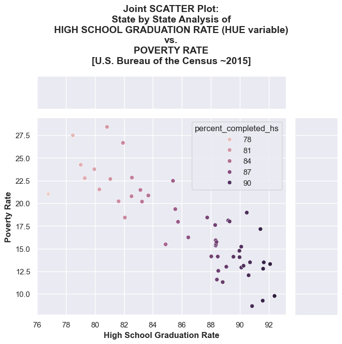

```python
with sns.axes_style('darkgrid'):
    grad_pov = sns.jointplot(
        df_state_hs_poverty,
        x='percent_completed_hs',
        y='poverty_rate',
        height=7,
        kind='scatter',
        hue='percent_completed_hs',
        legend='brief'
    )

sup_title = "Joint SCATTER Plot:\nState by State Analysis of\n"
sup_title += "HIGH SCHOOL GRADUATION RATE (HUE variable)\nvs.\nPOVERTY RATE\n"
sup_title += "[U.S. Bureau of the Census ~2015]"

grad_pov.figure.suptitle(sup_title,
                         size=14,
                         weight='bold')
grad_pov.figure.tight_layout()
# grad_pov.figure.subplots_adjust(top=0.865)

grad_pov.ax_joint.set_xlabel('High School Graduation Rate',
                             size=12,
                             weight='bold')
grad_pov.ax_joint.set_ylabel('Poverty Rate',
                             size=12,
                             weight='bold')

plt.show()
```

#### *Seaborn `joinplot()`: `kind=scatter` w/`kdeplot()` & `rugplot()`:*

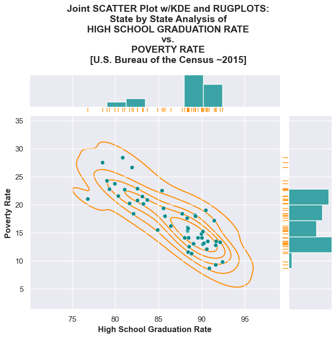

```python
with sns.axes_style('darkgrid'):
    grad_pov = sns.jointplot(
        df_state_hs_poverty,
        x='percent_completed_hs',
        y='poverty_rate',
        height=7,
        kind='scatter',
        color='darkcyan',
    )

grad_pov.plot_joint(sns.kdeplot, color="darkorange", zorder=0, levels=6)
grad_pov.plot_marginals(sns.rugplot, color="darkorange", height=-.15, clip_on=False)

sup_title = "Joint SCATTER Plot w/KDE and RUGPLOTS:\n"
sup_title += "State by State Analysis of\n"
sup_title += "HIGH SCHOOL GRADUATION RATE\nvs.\nPOVERTY RATE\n"
sup_title += "[U.S. Bureau of the Census ~2015]"

grad_pov.figure.suptitle(sup_title,
                         size=14,
                         weight='bold')
grad_pov.figure.tight_layout()

grad_pov.ax_joint.set_xlabel('High School Graduation Rate',
                             size=12,
                             weight='bold')
grad_pov.ax_joint.set_ylabel('Poverty Rate',
                             size=12,
                             weight='bold')

plt.show()
```

#### *Seaborn `joinplot()`: `kind=kde` w/`rugplot()`:*

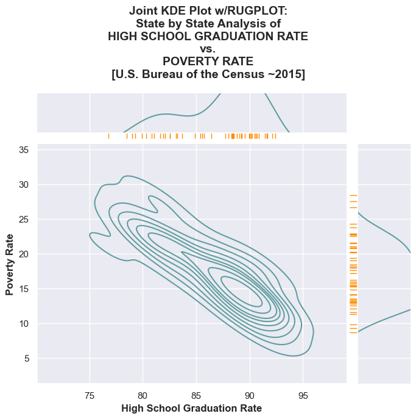

```python
with sns.axes_style('darkgrid'):
    grad_pov = sns.jointplot(
        df_state_hs_poverty,
        x='percent_completed_hs',
        y='poverty_rate',
        height=7,
        kind='kde',
        color='cadetblue',
    )

grad_pov.plot_marginals(sns.rugplot, color="darkorange", height=-.15, clip_on=False)

sup_title = "Joint KDE Plot w/RUGPLOT:\n"
sup_title += "State by State Analysis of\n"
sup_title += "HIGH SCHOOL GRADUATION RATE\nvs.\nPOVERTY RATE\n"
sup_title += "[U.S. Bureau of the Census ~2015]"

grad_pov.figure.suptitle(sup_title,
                         size=14,
                         weight='bold')
grad_pov.figure.tight_layout()

grad_pov.ax_joint.set_xlabel('High School Graduation Rate',
                             size=12,
                             weight='bold')
grad_pov.ax_joint.set_ylabel('Poverty Rate',
                             size=12,
                             weight='bold')

plt.show()
```

#### *Analysis:*

The heaviest clustering is around states with high graduation rates and low poverty rates.

This means there are more states with this combination of positive attributes, and that there are fewer states that have a combination of the more upsetting high poverty and low graduation rates. I would guess, and we'll see upon further analysis, that the instance of more violence upon civilians by police may be more concentrated in these states that have lower grad rates and high poverty rates...we'll see...

#### Seaborn's `.lmplot()` or `.regplot()` to show a linear regression between the poverty ratio and the high school graduation ratio.

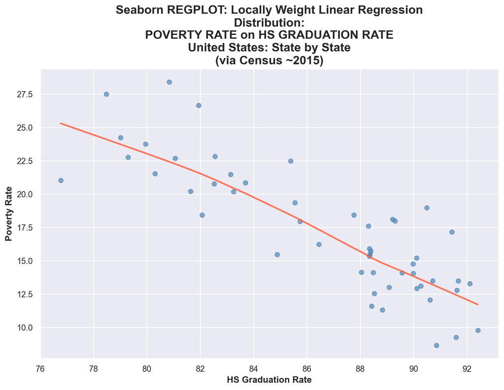

```python
plt.figure(figsize=(11, 7), dpi=200)

with sns.axes_style('darkgrid'):
    sns.regplot(data=df_state_hs_poverty,
                x='percent_completed_hs',
                y='poverty_rate',
                lowess=True,
                scatter_kws={'color': 'steelblue', 'alpha': 0.65},
                line_kws={'color': 'tomato', 'alpha': 0.85})

title = "Seaborn REGPLOT: Locally Weight Linear Regression\n"
title += "Distribution:\nPOVERTY RATE on HS GRADUATION RATE\n"
title += "United States: State by State\n(via Census ~2015)"
plt.title(title, size=16, weight='bold')

plt.xlabel("HS Graduation Rate", size=12, weight='bold')
plt.ylabel("Poverty Rate", size=12, weight='bold')

plt.show()
```

```python
from random import choices

seaborn_markers = ['o', '^', 'v', '<', '>', 's', 'D', 'd', 'p', 'h', 'H', '8',
                   'X', '*', '.', 'P', 'x', '+', '1', '2', '3', '4', '|', '_']

plot_markers = choices(seaborn_markers,
                       k=len(df_state_hs_poverty['State_Names']))
```

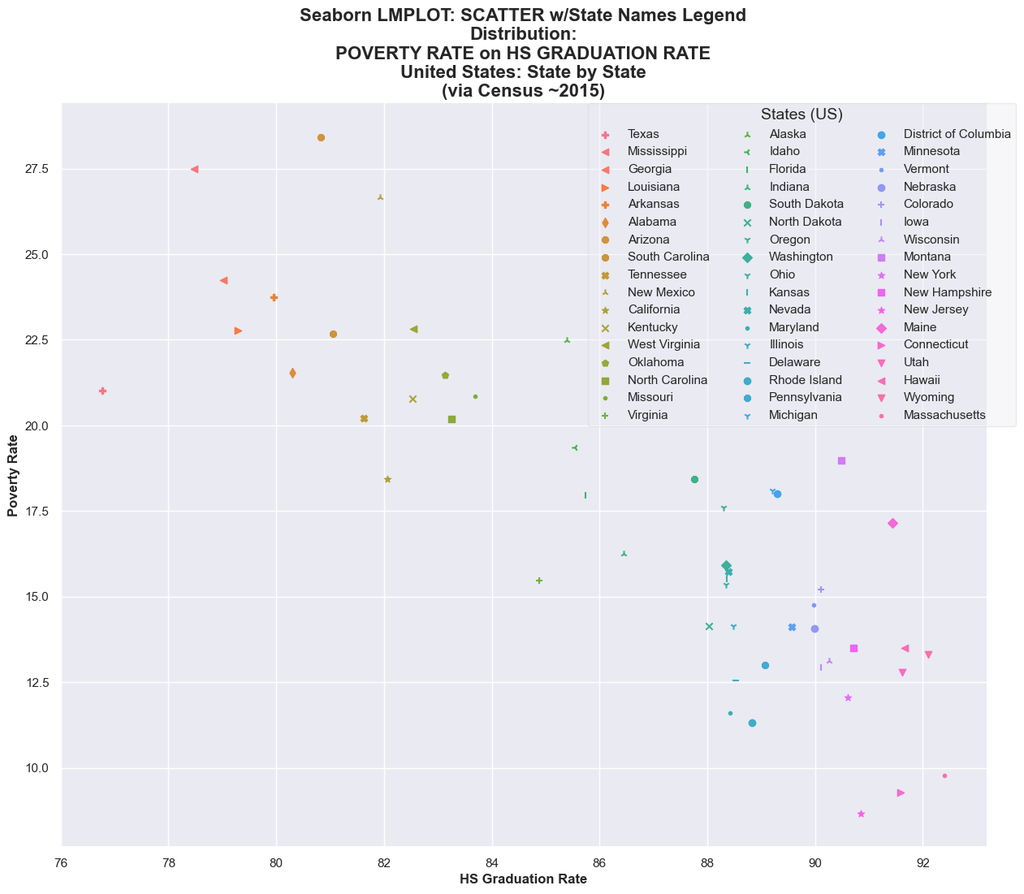

```python
with sns.axes_style('darkgrid'):
    ax = sns.lmplot(data=df_state_hs_poverty,
                    x='percent_completed_hs',
                    y='poverty_rate',
                    hue='State_Names',
                    height=10,
                    legend=True,
                    aspect=1.25,
                    markers=plot_markers,
                    fit_reg=True,
                    scatter_kws={'alpha': 0.95},
                    facet_kws={'legend_out': True})

sns.move_legend(ax,
                1,
                title='States (US)',
                title_fontsize=14,
                bbox_to_anchor=(.89, .99),
                ncols=3,
                frameon=True,
                fancybox=True,
                framealpha=.35)

title = "Seaborn LMPLOT: SCATTER w/State Names Legend\n"
title += "Distribution:\nPOVERTY RATE on HS GRADUATION RATE\n"
title += "United States: State by State\n(via Census ~2015)"

plt.title(title, size=16, weight='bold')

plt.xlabel("HS Graduation Rate", size=12, weight='bold')
plt.ylabel("Poverty Rate", size=12, weight='bold')

plt.show()
```

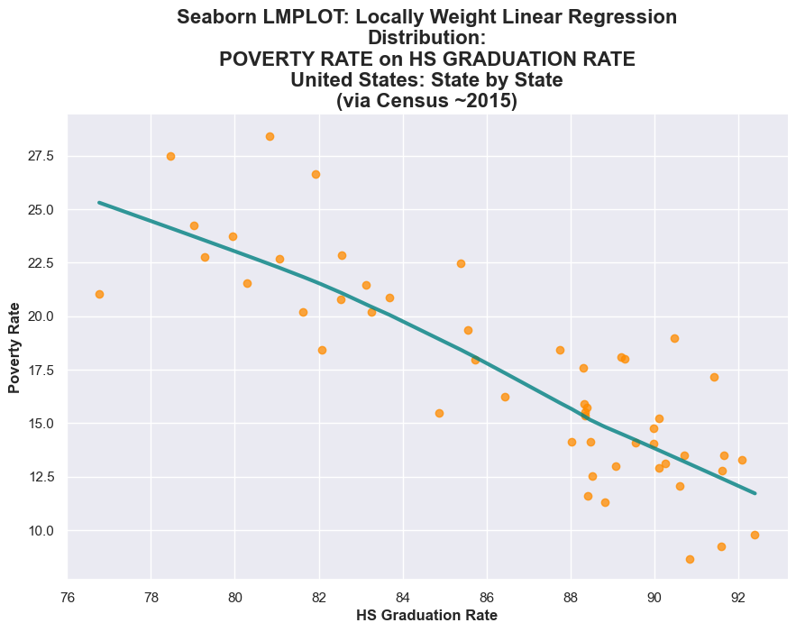

```python
with sns.axes_style('darkgrid'):
    sns.lmplot(
        data=df_state_hs_poverty,
        x='percent_completed_hs',
        y='poverty_rate',
        height=6,
        lowess=True,
        aspect=1.5,
        scatter_kws={'alpha': 0.75, 'color': 'darkorange'},
        line_kws={'alpha': .8, 'linewidth': 3, 'color': 'teal'},
    )

title = "Seaborn LMPLOT: Locally Weight Linear Regression\n"
title += "Distribution:\nPOVERTY RATE on HS GRADUATION RATE\n"
title += "United States: State by State\n(via Census ~2015)"
plt.title(title, size=16, weight='bold')

plt.xlabel("HS Graduation Rate", size=12, weight='bold')
plt.ylabel("Poverty Rate", size=12, weight='bold')

plt.show()
```

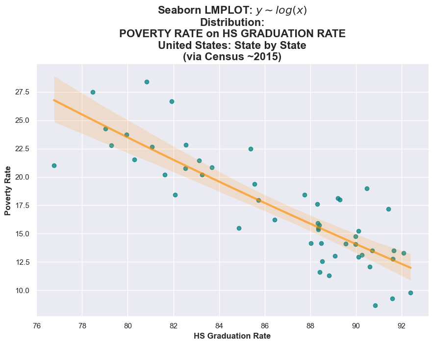

```python
with sns.axes_style('darkgrid'):
    sns.lmplot(
        data=df_state_hs_poverty,
        x='percent_completed_hs',
        y='poverty_rate',
        height=6,
        logx=True,
        aspect=1.5,
        fit_reg=True,
        scatter_kws={'alpha': 0.75, 'color': 'teal'},
        line_kws={'alpha': .65, 'linewidth': 3, 'color': 'darkorange'},
    )

title = "Seaborn LMPLOT: $y \\sim log(x)$\n"
title += "Distribution:\nPOVERTY RATE on HS GRADUATION RATE\n"
title += "United States: State by State\n(via Census ~2015)"
plt.title(title, size=16, weight='bold')

plt.xlabel("HS Graduation Rate", size=12, weight='bold')
plt.ylabel("Poverty Rate", size=12, weight='bold')

plt.show()
```

#### *Analysis:*

Based on the fact that all lot of the points in the scatterplots are close to the linear regression line plot, it appears there is a relationship between poverty level and high school graduation level.

# *Create a Bar Chart...*

### *...with Subsections Showing the Racial Makeup of Each US State*

Visualise the share of the white, black, hispanic, asian and native american population in each US State using a bar chart with sub sections.

#### *Inspect and transform `df_share_race_city`:*

```python
# Create copy of original DF in case we make a mistake:
df_race_city = df_share_race_city.copy()
```

```python
print(df_race_city.columns)
print(df_race_city.dtypes)
```

```
Index(['Geographic area', 'City', 'share_white', 'share_black',
       'share_native_american', 'share_asian', 'share_hispanic'],
      dtype='object')
Geographic area          object
City                     object
share_white              object
share_black              object
share_native_american    object
share_asian              object
share_hispanic           object
dtype: object
```

```python
# Inspect:
# df_race_city
```

```python
race_cols = ['share_white',
             'share_black',
             'share_native_american',
             'share_asian',
             'share_hispanic']

# Inspect all columns to see if data has non-digit strings:
for col in race_cols:
    for i in df_race_city[col]:
        if not i.isdigit():
            print(col)
            break
```

```
share_white
share_black
share_native_american
share_asian
share_hispanic
```

```python
# Entries w/non-digit strings are meant to be '0', let's replace them:
for col in race_cols:
    df_race_city[col] = df_race_city[col].replace(r'[^\d\.]', '0', regex=True)
```

```python
# Convert data to numeric values:
for col in race_cols:
    df_race_city[col] = pd.to_numeric(df_race_city[col])
```

```python
# Inspect the cleaned, transformed DF:
print(df_race_city.dtypes)
print(df_race_city.shape)
df_race_city.describe()
```

```
Geographic area           object
City                      object
share_white              float64
share_black              float64
share_native_american    float64
share_asian              float64
share_hispanic           float64
dtype: object
(29268, 7)
```

|  | share_white | share_black | share_native_american | share_asian | share_hispanic |
| --- | --- | --- | --- | --- | --- |
| count | 29,268.00 | 29,268.00 | 29,268.00 | 29,268.00 | 29,268.00 |
| mean | 83.16 | 6.83 | 2.87 | 1.54 | 9.32 |
| std | 21.76 | 15.61 | 12.67 | 4.29 | 17.57 |
| min | 0.00 | 0.00 | 0.00 | 0.00 | 0.00 |
| 25% | 78.50 | 0.10 | 0.10 | 0.00 | 1.20 |
| 50% | 92.50 | 0.80 | 0.30 | 0.40 | 2.90 |
| 75% | 96.90 | 4.20 | 0.90 | 1.20 | 8.00 |
| max | 100.00 | 100.00 | 100.00 | 67.10 | 100.00 |

```python
# Drop City column so next cell will work:
df_race_city = df_race_city.drop(columns=['City'])
```

```python
df_race_state = df_race_city.groupby('Geographic area').mean().reset_index()
```

```python
# Inspect new DF:
display(df_race_state)
print(df_race_state.dtypes)
print(df_race_state.shape)
df_race_state.describe()
```

|  | Geographic area | share_white | share_black | share_native_american | share_asian | share_hispanic |
| --- | --- | --- | --- | --- | --- | --- |
| 0 | AK | 45.26 | 0.56 | 45.48 | 1.38 | 2.13 |
| 1 | AL | 72.51 | 23.32 | 0.66 | 0.48 | 2.98 |
| 2 | AR | 78.45 | 16.30 | 0.76 | 0.48 | 4.27 |
| 3 | AZ | 59.93 | 0.95 | 28.59 | 0.73 | 20.14 |
| 4 | CA | 71.54 | 2.68 | 1.72 | 5.54 | 29.51 |
| 5 | CO | 87.77 | 0.92 | 1.62 | 1.15 | 17.90 |
| 6 | CT | 86.11 | 4.99 | 0.66 | 2.99 | 7.98 |
| 7 | DC | 38.50 | 50.70 | 0.30 | 3.50 | 9.10 |
| 8 | DE | 76.25 | 15.39 | 0.52 | 2.00 | 7.42 |
| 9 | FL | 78.67 | 13.37 | 0.46 | 1.62 | 16.53 |
| 10 | GA | 62.59 | 30.63 | 0.30 | 1.49 | 6.42 |
| 11 | HI | 33.37 | 1.07 | 0.39 | 25.65 | 10.36 |
| 12 | IA | 96.71 | 0.56 | 0.27 | 0.40 | 2.82 |
| 13 | ID | 88.82 | 0.30 | 2.52 | 0.49 | 10.70 |
| 14 | IL | 90.36 | 4.70 | 0.26 | 1.34 | 5.17 |
| 15 | IN | 94.82 | 1.69 | 0.28 | 0.59 | 3.32 |
| 16 | KS | 92.96 | 0.96 | 1.87 | 0.43 | 5.07 |
| 17 | KY | 92.23 | 4.42 | 0.21 | 0.71 | 2.23 |
| 18 | LA | 64.81 | 30.78 | 0.96 | 0.79 | 2.98 |
| 19 | MA | 89.30 | 2.79 | 0.27 | 2.84 | 4.93 |
| 20 | MD | 72.12 | 19.46 | 0.34 | 2.98 | 5.93 |
| 21 | ME | 95.69 | 0.82 | 0.55 | 1.03 | 1.31 |
| 22 | MI | 90.67 | 4.12 | 1.08 | 0.95 | 3.54 |
| 23 | MN | 91.80 | 1.00 | 3.36 | 1.03 | 3.15 |
| 24 | MO | 90.18 | 5.86 | 0.54 | 0.55 | 2.36 |
| 25 | MS | 53.80 | 41.83 | 1.61 | 0.55 | 2.32 |
| 26 | MT | 84.48 | 0.23 | 11.87 | 0.32 | 2.19 |
| 27 | NC | 71.52 | 20.40 | 1.79 | 0.93 | 6.41 |
| 28 | ND | 92.29 | 0.36 | 5.33 | 0.29 | 1.82 |
| 29 | NE | 94.72 | 0.42 | 1.56 | 0.29 | 4.07 |
| 30 | NH | 95.68 | 0.72 | 0.29 | 1.34 | 1.74 |
| 31 | NJ | 80.89 | 6.98 | 0.26 | 5.94 | 11.12 |
| 32 | NM | 65.42 | 0.67 | 15.34 | 0.49 | 45.43 |
| 33 | NV | 82.33 | 1.57 | 5.58 | 2.01 | 13.17 |
| 34 | NY | 88.88 | 4.01 | 0.36 | 2.72 | 6.63 |
| 35 | OH | 92.80 | 3.96 | 0.22 | 0.75 | 2.13 |
| 36 | OK | 72.93 | 3.38 | 14.38 | 0.43 | 5.70 |
| 37 | OR | 87.39 | 0.53 | 2.58 | 1.38 | 9.75 |
| 38 | PA | 93.25 | 3.27 | 0.16 | 0.99 | 2.73 |
| 39 | RI | 89.23 | 2.99 | 0.67 | 1.69 | 6.67 |
| 40 | SC | 61.98 | 32.83 | 0.46 | 0.74 | 4.48 |
| 41 | SD | 84.82 | 0.29 | 12.03 | 0.32 | 2.04 |
| 42 | TN | 88.95 | 7.30 | 0.32 | 0.64 | 2.86 |
| 43 | TX | 82.40 | 5.87 | 0.66 | 1.01 | 39.27 |
| 44 | UT | 89.44 | 0.38 | 3.87 | 0.77 | 7.66 |
| 45 | VA | 74.60 | 16.51 | 0.34 | 3.67 | 6.15 |
| 46 | VT | 95.87 | 0.77 | 0.37 | 0.91 | 1.38 |
| 47 | WA | 82.38 | 1.43 | 3.75 | 3.07 | 10.61 |
| 48 | WI | 92.96 | 0.94 | 2.62 | 0.79 | 3.32 |
| 49 | WV | 95.04 | 2.92 | 0.20 | 0.34 | 0.90 |
| 50 | WY | 91.92 | 0.40 | 3.08 | 0.39 | 5.99 |

```
Geographic area           object
share_white              float64
share_black              float64
share_native_american    float64
share_asian              float64
share_hispanic           float64
dtype: object
(51, 6)
```

|  | share_white | share_black | share_native_american | share_asian | share_hispanic |
| --- | --- | --- | --- | --- | --- |
| count | 51.00 | 51.00 | 51.00 | 51.00 | 51.00 |
| mean | 80.93 | 7.83 | 3.60 | 1.84 | 7.74 |
| std | 15.20 | 11.67 | 7.88 | 3.63 | 8.92 |
| min | 33.37 | 0.23 | 0.16 | 0.29 | 0.90 |
| 25% | 72.72 | 0.80 | 0.33 | 0.52 | 2.78 |
| 50% | 87.39 | 2.92 | 0.66 | 0.93 | 5.07 |
| 75% | 92.07 | 7.14 | 2.60 | 1.65 | 8.54 |
| max | 96.71 | 50.70 | 45.48 | 25.65 | 45.43 |

```python
# Rename 'Geographic area' to 'state_abbr':
df_race_state.rename({'Geographic area': 'state_abbr'}, axis=1, inplace=True)
```

```python
# Add a column with state names:
state_dict = {"TX": "Texas", "MS": "Mississippi", "GA": "Georgia", "LA": "Louisiana", "AR": "Arkansas", "AL": "Alabama", "AZ": "Arizona", "SC": "South Carolina", "TN": "Tennessee", "NM": "New Mexico", "CA": "California", "KY": "Kentucky", "WV": "West Virginia", "OK": "Oklahoma", "NC": "North Carolina", "MO": "Missouri", "VA": "Virginia", "AK": "Alaska", "ID": "Idaho", "FL": "Florida", "IN": "Indiana", "SD": "South Dakota", "ND": "North Dakota", "OR": "Oregon", "WA": "Washington", "OH": "Ohio", "KS": "Kansas", "NV": "Nevada", "MD": "Maryland", "IL": "Illinois", "DE": "Delaware", "RI": "Rhode Island", "PA": "Pennsylvania", "MI": "Michigan", "DC": "District of Columbia", "MN": "Minnesota", "VT": "Vermont", "NE": "Nebraska", "CO": "Colorado", "IA": "Iowa", "WI": "Wisconsin", "MT": "Montana", "NY": "New York", "NH": "New Hampshire", "NJ": "New Jersey", "ME": "Maine", "CT": "Connecticut", "UT": "Utah", "HI": "Hawaii", "WY": "Wyoming", "MA": "Massachusetts"}

state_names= np.array([state_dict.get(i) for i in df_race_state['state_abbr']],
                      dtype='object')

df_race_state.insert(1, 'state_name', state_names)
```

```python
# Verify the rows each add up to about `100`:
df_race_state
```

|  | state_abbr | state_name | share_white | share_black | share_native_american | share_asian | share_hispanic |
| --- | --- | --- | --- | --- | --- | --- | --- |
| 0 | AK | Alaska | 45.26 | 0.56 | 45.48 | 1.38 | 2.13 |
| 1 | AL | Alabama | 72.51 | 23.32 | 0.66 | 0.48 | 2.98 |
| 2 | AR | Arkansas | 78.45 | 16.30 | 0.76 | 0.48 | 4.27 |
| 3 | AZ | Arizona | 59.93 | 0.95 | 28.59 | 0.73 | 20.14 |
| 4 | CA | California | 71.54 | 2.68 | 1.72 | 5.54 | 29.51 |
| 5 | CO | Colorado | 87.77 | 0.92 | 1.62 | 1.15 | 17.90 |
| 6 | CT | Connecticut | 86.11 | 4.99 | 0.66 | 2.99 | 7.98 |
| 7 | DC | District of Columbia | 38.50 | 50.70 | 0.30 | 3.50 | 9.10 |
| 8 | DE | Delaware | 76.25 | 15.39 | 0.52 | 2.00 | 7.42 |
| 9 | FL | Florida | 78.67 | 13.37 | 0.46 | 1.62 | 16.53 |
| 10 | GA | Georgia | 62.59 | 30.63 | 0.30 | 1.49 | 6.42 |
| 11 | HI | Hawaii | 33.37 | 1.07 | 0.39 | 25.65 | 10.36 |
| 12 | IA | Iowa | 96.71 | 0.56 | 0.27 | 0.40 | 2.82 |
| 13 | ID | Idaho | 88.82 | 0.30 | 2.52 | 0.49 | 10.70 |
| 14 | IL | Illinois | 90.36 | 4.70 | 0.26 | 1.34 | 5.17 |
| 15 | IN | Indiana | 94.82 | 1.69 | 0.28 | 0.59 | 3.32 |
| 16 | KS | Kansas | 92.96 | 0.96 | 1.87 | 0.43 | 5.07 |
| 17 | KY | Kentucky | 92.23 | 4.42 | 0.21 | 0.71 | 2.23 |
| 18 | LA | Louisiana | 64.81 | 30.78 | 0.96 | 0.79 | 2.98 |
| 19 | MA | Massachusetts | 89.30 | 2.79 | 0.27 | 2.84 | 4.93 |
| 20 | MD | Maryland | 72.12 | 19.46 | 0.34 | 2.98 | 5.93 |
| 21 | ME | Maine | 95.69 | 0.82 | 0.55 | 1.03 | 1.31 |
| 22 | MI | Michigan | 90.67 | 4.12 | 1.08 | 0.95 | 3.54 |
| 23 | MN | Minnesota | 91.80 | 1.00 | 3.36 | 1.03 | 3.15 |
| 24 | MO | Missouri | 90.18 | 5.86 | 0.54 | 0.55 | 2.36 |
| 25 | MS | Mississippi | 53.80 | 41.83 | 1.61 | 0.55 | 2.32 |
| 26 | MT | Montana | 84.48 | 0.23 | 11.87 | 0.32 | 2.19 |
| 27 | NC | North Carolina | 71.52 | 20.40 | 1.79 | 0.93 | 6.41 |
| 28 | ND | North Dakota | 92.29 | 0.36 | 5.33 | 0.29 | 1.82 |
| 29 | NE | Nebraska | 94.72 | 0.42 | 1.56 | 0.29 | 4.07 |
| 30 | NH | New Hampshire | 95.68 | 0.72 | 0.29 | 1.34 | 1.74 |
| 31 | NJ | New Jersey | 80.89 | 6.98 | 0.26 | 5.94 | 11.12 |
| 32 | NM | New Mexico | 65.42 | 0.67 | 15.34 | 0.49 | 45.43 |
| 33 | NV | Nevada | 82.33 | 1.57 | 5.58 | 2.01 | 13.17 |
| 34 | NY | New York | 88.88 | 4.01 | 0.36 | 2.72 | 6.63 |
| 35 | OH | Ohio | 92.80 | 3.96 | 0.22 | 0.75 | 2.13 |
| 36 | OK | Oklahoma | 72.93 | 3.38 | 14.38 | 0.43 | 5.70 |
| 37 | OR | Oregon | 87.39 | 0.53 | 2.58 | 1.38 | 9.75 |
| 38 | PA | Pennsylvania | 93.25 | 3.27 | 0.16 | 0.99 | 2.73 |
| 39 | RI | Rhode Island | 89.23 | 2.99 | 0.67 | 1.69 | 6.67 |
| 40 | SC | South Carolina | 61.98 | 32.83 | 0.46 | 0.74 | 4.48 |
| 41 | SD | South Dakota | 84.82 | 0.29 | 12.03 | 0.32 | 2.04 |
| 42 | TN | Tennessee | 88.95 | 7.30 | 0.32 | 0.64 | 2.86 |
| 43 | TX | Texas | 82.40 | 5.87 | 0.66 | 1.01 | 39.27 |
| 44 | UT | Utah | 89.44 | 0.38 | 3.87 | 0.77 | 7.66 |
| 45 | VA | Virginia | 74.60 | 16.51 | 0.34 | 3.67 | 6.15 |
| 46 | VT | Vermont | 95.87 | 0.77 | 0.37 | 0.91 | 1.38 |
| 47 | WA | Washington | 82.38 | 1.43 | 3.75 | 3.07 | 10.61 |
| 48 | WI | Wisconsin | 92.96 | 0.94 | 2.62 | 0.79 | 3.32 |
| 49 | WV | West Virginia | 95.04 | 2.92 | 0.20 | 0.34 | 0.90 |
| 50 | WY | Wyoming | 91.92 | 0.40 | 3.08 | 0.39 | 5.99 |

#### *The new df `df_race_state` is good to go!*

#### *Now the plot:*

Visualise the share of the white, black, hispanic, asian and native american population in each US State using a bar chart with sub sections.

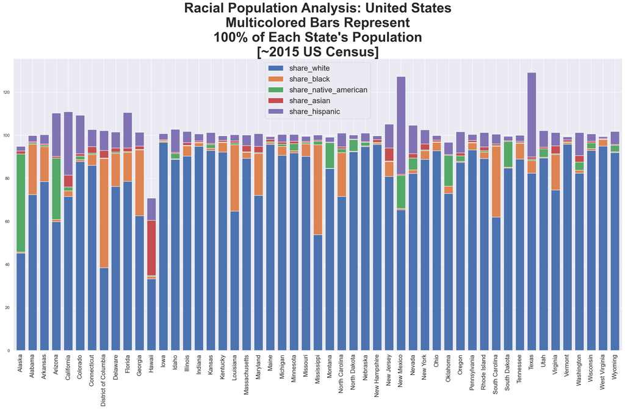

```python
ax = df_race_state.plot(figsize=(29, 14),
                        stacked=True,
                        width=0.75,
                        kind='bar',
                        legend=True,
                        xticks=df_race_state.index)

ax.set_xticklabels(df_race_state['state_name'])


title = "Racial Population Analysis: United States\n"
title += "Multicolored Bars Represent\n100% of Each State's Population\n"
title += "[~2015 US Census]"

plt.title(title, size=36, weight='bold')
ax.tick_params(axis='x', which='major', labelsize=16)

plt.legend(fontsize=20)

plt.show()
```

#### *Analysis:*

*First of all...*

...the bars are not all equal to 100 -- which probably means:

- Taking the average of each column's values throws off the aggregate to 100 -- since we're taking the average along Axis 0 for an aggregate to 100 which would be along Axis 1
  - I think the general result should still be representative of the shares represented by each column, but upon a refactor will find a way to even out this phenomenon.

I'll ignore this issue, since it seems negligible/a matter for future fine-tuning, and likely doesn't affect the accuracy of the overall accuracy of the racial breakdown for each state.

*And B...*

We can sort the plots by which percentage of each state is highest for each race for futher analysis, but for now we can clearly which states have the highest population of each race:

- African American: Washington DC
- Caucasian: Maine/New Hampshire/West Virginia
- Asian: Hawaii
- Latino: New Mexico or Texas
- Native American: Alaska

# *Create Donut Chart...*

### *...of People Killed by Race*

Hint: Use `.value_counts()`

#### *Data Cleaning and Transformation:*

```python
race_counts = df_fatalities['race'].value_counts()

# Inspect:
# df_fatalities['race'].value_counts().nlargest(10)
# df_fatalities['race'].value_counts().nlargest(10).index
```

```python
race_counts
```

```
race
W    1201
B     618
H     423
0     195
A      39
N      31
O      28
Name: count, dtype: int64
```

```python
# Replace `0` with `O` (undetermined):
df_fatalities['race'] = df_fatalities['race'].replace(0, 'O')
```

```python
race_counts = df_fatalities['race'].value_counts()
```

```python
# Now we have one metric for undetermined:
race_counts
```

```
race
W    1201
B     618
H     423
O     223
A      39
N      31
Name: count, dtype: int64
```

```python
# Though, for clarity, let's rename to words rather than abbreviations:
race_dict = {'W': 'Caucasian', 'B': 'African American', 'H': 'Latino',
             'A': 'Asian American', 'N': 'Native American', 'O': 'Undetermined'}

df_fatalities['race'] = df_fatalities['race'].replace(race_dict)
```

```python
# Drop the `id` column (we're not working w/relational databases):
df_fatalities.drop(columns=['id'], inplace=True)
```

```python
# Now create `race_counts` again:
race_counts = df_fatalities['race'].value_counts()
```

```python
# This is much clearer than before:
print(race_counts)
print(race_counts.index)
print(race_counts.values)
```

```
race
Caucasian           1201
African American     618
Latino               423
Undetermined         223
Asian American        39
Native American       31
Name: count, dtype: int64
Index(['Caucasian', 'African American', 'Latino', 'Undetermined',
       'Asian American', 'Native American'],
      dtype='object', name='race')
[1201  618  423  223   39   31]
```

#### *Create Donut Chart of People Killed by Race:*

*Hint: Use `.value_counts()`*

```python
from random import choices

colors = ['sienna', 'steelblue', 'olivedrab',
          'darkslategrey', 'firebrick', 'rebeccapurple']

title = "People Killed by Police in the US by Race, 2015-2017"

fig = px.pie(
    labels=race_counts.index,
    values=race_counts.values,
    title=title,
    names=race_counts.index,
    hole=0.25,
    width=1280,
    height=1280,
    color_discrete_sequence=colors
)

fig.update_traces(
    textposition='inside',
    textfont=dict(family='tahoma', size=16, color='gainsboro'),
    textinfo='percent',
)

fig.update_layout(
    title=dict(font=dict(size=36)),
)

fig.show()
```

#### *Analysis:*

In order from highest percentage to lowest:

- Caucasian: $47.4\%$
- African American: $24.4\%$
- Latino: $16.7\%$
- Undetermined: $8.8\%$
- Asian American: $1.54\%$
- Native American: $1.22\%$

# *Create a Chart Comparing the Total Number of Deaths of Men and Women*

Use `df_fatalities` to illustrate how many more men are killed compared to women.

```python
df_fatalities.sample()
```

|  | name | date | manner_of_death | armed | age | gender | race | city | state | signs_of_mental_illness | threat_level | flee | body_camera |
| --- | --- | --- | --- | --- | --- | --- | --- | --- | --- | --- | --- | --- | --- |
| 1724 | Donte T. Jones | 02/10/16 | shot | unknown weapon | 36.00 | M | African American | Markham | IL | False | other | Not fleeing | False |

```python
gender_counts = df_fatalities['gender'].value_counts()
```

```python
# Replace abbreviations with full words:
gender_dict = {'M': 'Male', 'F': 'Female'}

df_fatalities['gender'] = df_fatalities['gender'].replace(gender_dict)
```

```python
gender_counts = df_fatalities['gender'].value_counts()
```

```python
gender_counts
```

```
gender
Male      2428
Female     107
Name: count, dtype: int64
```

```python
from random import choices

colors = ['steelblue', 'firebrick']

title = "People Killed by Police in the US by Gender, 2015-2017"

fig = px.pie(
    labels=gender_counts.index,
    values=gender_counts.values,
    title=title,
    names=gender_counts.index,
    hole=0.25,
    width=840,
    height=840,
    color_discrete_sequence=colors
)

fig.update_traces(
    textposition='inside',
    textfont=dict(family='tahoma', size=12, color='gainsboro'),
    textinfo='percent',
)

fig.update_layout(
    title=dict(font=dict(size=24)),
)

fig.show()
```

#### *Analysis:*

Men killed by police: $95.8\%$

Women killed by police: $4.22\%$

# *Create a Box Plot Showing the Age and Manner of Death*

Break out the data by gender using `df_fatalities`. Is there a difference between men and women in the manner of death?

```python
df_fatalities.dtypes
```

```
name                        object
date                        object
manner_of_death             object
armed                       object
age                        float64
gender                      object
race                        object
city                        object
state                       object
signs_of_mental_illness       bool
threat_level                object
flee                        object
body_camera                   bool
dtype: object
```

```python
# Inspect for non-numeric values:
for i in df_fatalities['age'].value_counts().index:
    print(i)

# All good
```

```python
# Inspect:
df_fatalities['manner_of_death'].value_counts()
```

```
manner_of_death
shot                2363
shot and Tasered     172
Name: count, dtype: int64
```

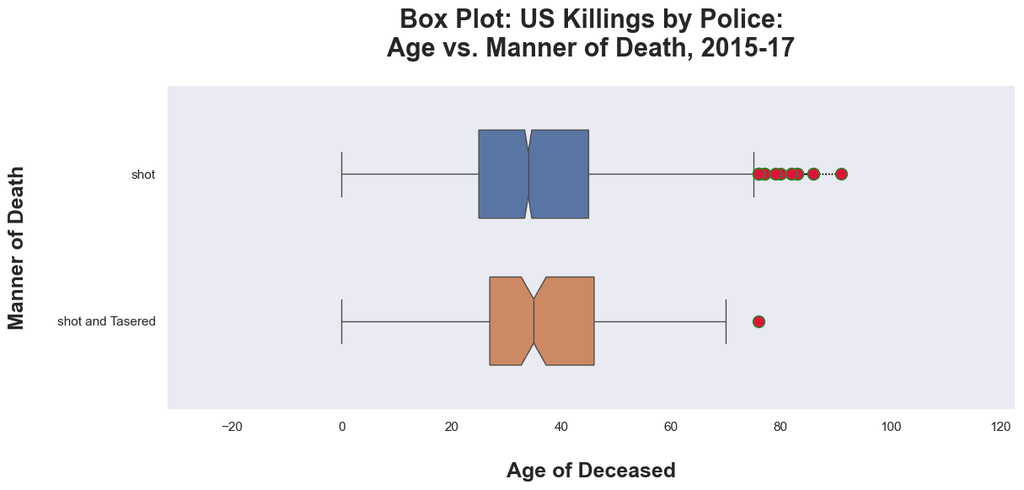

```python
plt.figure(figsize=(13, 5))

sns.boxplot(
    data=df_fatalities,
    x='age',
    y='manner_of_death',
    width=0.6,
    notch=True,
    flierprops={"marker": "o",
                "markersize": 10,
                'markerfacecolor': 'crimson',
                'markeredgecolor': 'forestgreen',
                'linestyle': 'dotted'},
    hue='manner_of_death'
)

plt.title('Box Plot: US Killings by Police:\nAge vs. Manner of Death, 2015-17',
          fontdict={'size': 22, 'weight': 'bold'},
          pad=25.0)

plt.xlabel('Age of Deceased',
           fontdict={'size': 18, 'weight': 'bold'},
           labelpad=25.0)
plt.ylabel('Manner of Death',
           fontdict={'size': 18, 'weight': 'bold'},
           labelpad=25.0)

plt.grid(axis='x')
plt.margins(0.35)

plt.show()
```

#### *Analysis:*

Most victims were between the ages of 25 and 45, with the age range slightly higher for `shot and Tasered`.

More outliers of higher age (above 75) for `shot`.

# *Were People Armed?*

In what percentage of police killings were people armed?

Create a chart that shows what kind of weapon (if any) the deceased was carrying.

How many of the people killed by police were armed with guns versus unarmed?

#### *In what percentage of police killings were people armed?*

```python
df_armed = df_fatalities[['armed']]
```

```python
# Search all entries and determine what might be considered 'unarmed':
for i in df_armed.value_counts().index:
    print(i)

# I'll use:
unarmed = ['unarmed', 'undetermined', 'unknown weapon', 0]
```

```python
# Change all 'unarmed'-type to explicitly 'unarmed':
for i in unarmed:
    df_armed['armed'] = df_armed['armed'].replace(i, 'unarmed')
```

```python
df_armed['armed'] = df_armed['armed'].mask(df_armed['armed'] != 'unarmed', 'armed')
```

```python
# Create series and check results:
armed_counts = df_armed.value_counts()
print(armed_counts)
```

```
armed
armed      2220
unarmed     315
Name: count, dtype: int64
```

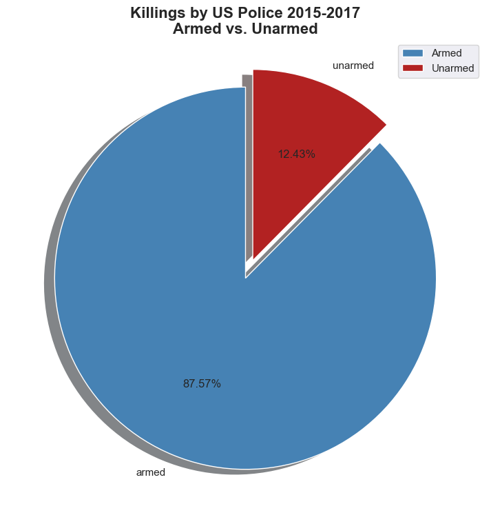

```python
fig, ax = plt.subplots(figsize=(9, 9))

labels = 'armed', 'unarmed'
explode = (0, 0.1)

ax.pie(
    armed_counts,
    explode=explode,
    labels=labels,
    autopct='%1.2f%%',
    shadow={'ox': -0.04, 'edgecolor': 'none', 'shade': 0.9},
    startangle=90,
    colors=['steelblue', 'firebrick'],
)

title = "Killings by US Police 2015-2017"
title += "\nArmed vs. Unarmed"
ax.set_title(title, size=16, weight='bold')

ax.legend(['Armed', 'Unarmed'])

plt.show()
```

#### *Analysis:*

$87.57\%$ Armed

$12.43\%$ Unarmed

#### *Create a chart that shows what kind of weapon (if any) the deceased was carrying.*

```python
armed_counts = df_fatalities['armed'].value_counts()
```

```python
# Make descriptive labels:
armed_zipped = list(zip(armed_counts.index, armed_counts))
armed_labels = [f"{i}: {j}" for i, j in armed_zipped]
```

```python
colors = [
    "black", "blue", "brown", "chocolate", "cornflowerblue", "crimson", "darkblue",
    "darkcyan", "darkgoldenrod", "darkgreen", "darkkhaki", "darkmagenta", "darkolivegreen",
    "darkorange", "darkorchid", "darkred", "darksalmon", "darkseagreen", "darkslateblue",
    "darkslategray", "darkslategrey", "darkturquoise", "darkviolet", "deeppink", "dimgray",
    "dodgerblue", "firebrick", "forestgreen", "goldenrod", "green", "greenyellow", "indigo",
    "lightgreen", "limegreen", "maroon", "mediumblue", "mediumseagreen", "mediumslateblue",
    "mediumspringgreen", "midnightblue", "navy", "olive", "olivedrab", "palegreen", "peru",
    "purple", "rebeccapurple", "rosybrown", "royalblue", "saddlebrown", "sandybrown",
    "seagreen", "sienna", "slateblue", "springgreen", "steelblue", "yellowgreen"
]
```

```python
# Plot it:
title = "Police Killings in the US: Type of Weapon Carried by Deceased , 2015-2017"

fig = px.pie(
    labels=armed_counts.index,
    values=armed_counts.values,
    title=title,
    names=armed_labels,
    hole=0.25,
    width=1920,
    height=1920,
    color_discrete_sequence=choices(colors, k=len(armed_counts.index)),
)

# Make labels outside if too small for text:

fig.update_traces(
    textposition='inside',
    textfont=dict(family='tahoma', size=14, color='gainsboro'),
    textinfo='percent',
    insidetextorientation='radial',
)

fig.update_layout(
    title=dict(font=dict(size=42)),
    legend=dict(entrywidth=0.3,
                entrywidthmode='fraction',
                orientation='h',
                y=-0.05,
                xanchor='center',
                x=0.6)
)

fig.show()
```

#### *Analysis:*

Most common weapon: *Gun*

Least common weapon: *Pen*

#### *How many of the people killed by police were armed with guns versus unarmed?*

```python
num_unarmed = df_armed.value_counts()['unarmed']
```

```python
num_guns = df_fatalities['armed'].value_counts()['gun']
```

```python
labels = [f"Armed with Guns: {num_guns}", f"Unarmed: {num_unarmed}"]
```

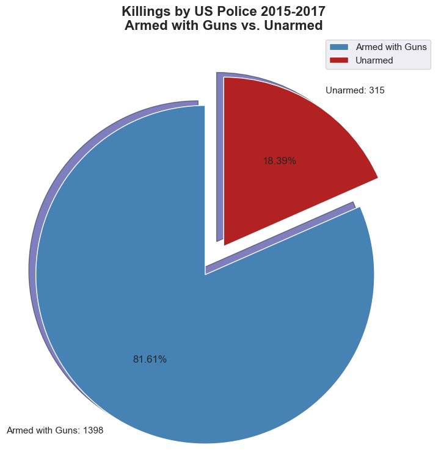

```python
fig, ax = plt.subplots(figsize=(9, 9))

explode = [0.2, 0]

ax.pie(
    [num_guns, num_unarmed],
    explode=explode,
    labels=labels,
    autopct='%1.2f%%',
    shadow={'ox': -0.03, 'oy': 0.02, 'edgecolor': 'k', 'facecolor': 'navy'},
    startangle=90,
    colors=['steelblue', 'firebrick'],
)

title = "Killings by US Police 2015-2017"
title += "\nArmed with Guns vs. Unarmed"
ax.set_title(title, size=16, weight='bold')

ax.legend(['Armed with Guns', 'Unarmed'])

plt.show()
```

#### *Analysis:*

Armed with guns:

- $1,398$
- $81.61\%$

Unarmed:

- $315$
- $18.39\%$

# *How Old Were the People Killed?*

#### *Work out what percentage of people killed were under 25 years old.*

```python
# Create a new row based on bool for `age < 25`
series_under_25 = df_fatalities['age'].apply(lambda x: 'under_25' if x < 25 else 'over_25')
```

```python
# Add row to the DF:
df_fatalities.insert(5, '>25<', series_under_25)
```

```python
# Create series to count age groups:
series_count_25 = df_fatalities['>25<'].value_counts()
```

```python
val_over = series_count_25['over_25']
val_under = series_count_25['under_25']
```

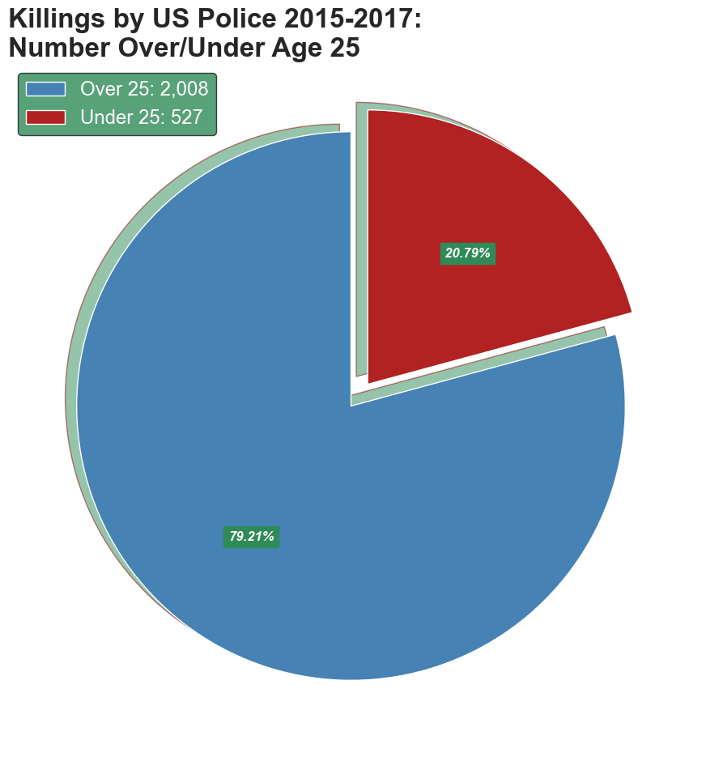

```python
fig, ax = plt.subplots(figsize=(11, 11))

labels = (f"Over 25: {val_over:,}", f"Under 25: {val_under:,}")
explode = (0, 0.1)

ax.pie(
    series_count_25,
    explode=explode,
    # labels=labels,
    autopct='%1.2f%%',
    shadow={'ox': -0.03,
            'oy': 0.02,
            'edgecolor': 'darkred',
            'facecolor': 'seagreen'},
    startangle=90,
    colors=['steelblue', 'firebrick'],
    textprops=dict(
        color='snow',
        backgroundcolor='seagreen',
        size=12,
        style='italic',
        weight='bold'
    ),
)

title = "Killings by US Police 2015-2017:\n"
title += "Number Over/Under Age 25"
ax.set_title(title, size=24, weight='bold', loc='left')

ax.legend(
    labels=labels,
    edgecolor='k',
    mode=None, # 'expand'
    facecolor='seagreen',
    fontsize='x-large',
    labelcolor='snow'
)

plt.show()
```

#### *Analysis:*

Over 25:

- $79.21\%$
- $2,008$ total

Under 25:

- $20.79\%$
- $527$ total

#### *Create a histogram and KDE plot that shows the distribution of ages of the people killed by police.*

```python
series_age = df_fatalities['age'].value_counts()
```

```python
for i in series_age:
    print(i)
```

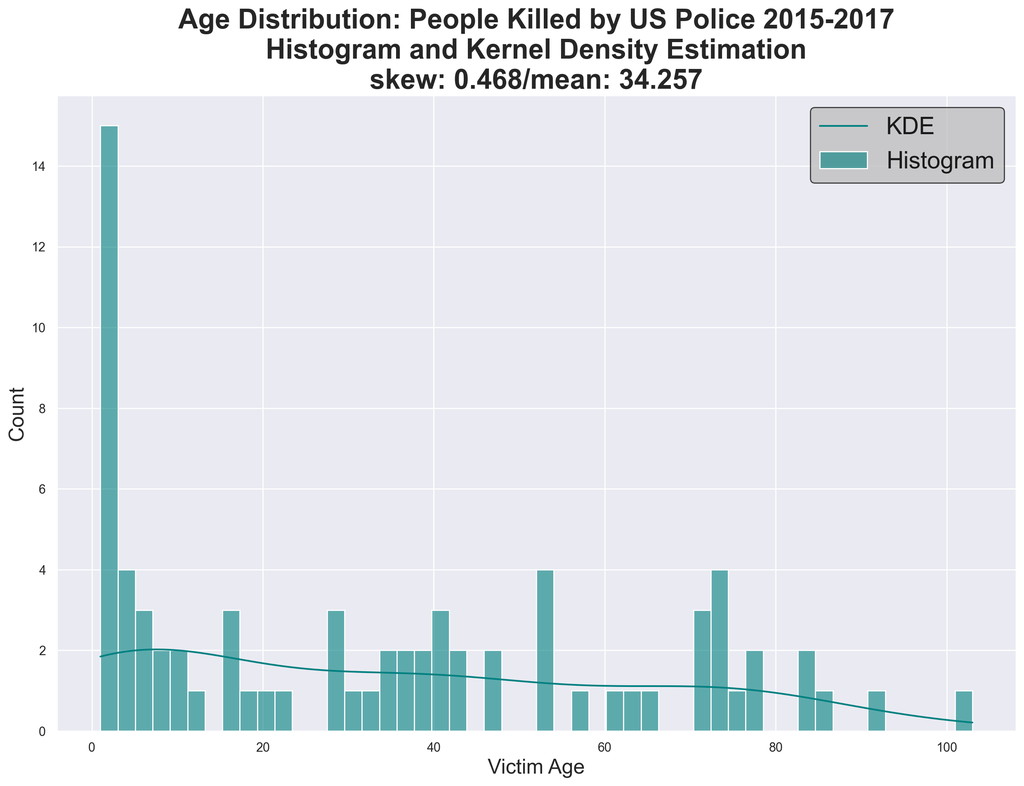

```python
series_age_skew = np.round(series_age.skew(), 3)
series_age_mean = np.round(series_age.mean(), 3)

fig, ax = plt.subplots(figsize=(15, 10), dpi=200)

sns.histplot(
    series_age,
    kde=True,
    color='teal',
    legend=False,
    ax=ax,
    alpha=0.6,
    bins=50,
    # line_kws={'color': 'crimson', 'lw': 5, 'ls': ':'}
)

sns.set_theme(style='darkgrid')

title = f"Age Distribution: People Killed by US Police 2015-2017\n"
title += f"Histogram and Kernel Density Estimation\n"
title += f"skew: {series_age_skew}/mean: {series_age_mean}"

plt.title(title, size=24, weight='bold')
plt.xlabel("Victim Age", fontsize=18)
plt.ylabel("Count", fontsize=18)

plt.legend(
    labels=['KDE', 'Histogram'],
    edgecolor='k',
    mode=None, # 'expand'
    facecolor='silver',
    fontsize='xx-large',
    labelcolor='k',
)

plt.show()
```

#### *Analysis:*

A skew of .468 indicates there are slightly more data points w/lower values.

The slightly decreasing KDE indicates there are slightly fewer data points in this dataset with higher values.

The histogram bars are much higher to the left, so this bears out the above conclusions.

Overall, the spread of data points is pretty even, but there is a spike of data points with smaller values.

#### *Create a seperate KDE plot for each race. Is there a difference between the distributions?*

```python
series_races = df_fatalities['race'].value_counts()
```

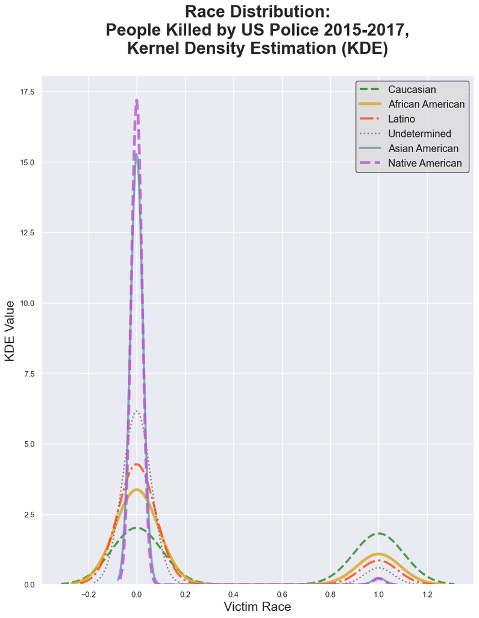

```python
plt.figure(figsize=(11, 13))

widths = [3, 4, 3, 2, 3, 4]
linestyles = ['--', '-', '-.', ':', '-', '--']
colors = ['forestgreen', 'goldenrod', 'orangered', 'dimgrey', 'cadetblue', 'mediumorchid']

for race in series_races.index:
    sns.kdeplot(
        df_fatalities['race'] == race,
        linewidth=widths.pop(0),
        linestyle=linestyles.pop(0),
        legend=True,
        color=colors.pop(0),
        alpha=0.8,
        # fill=True,
    )

sns.set_theme(style='darkgrid')

title = f"Race Distribution:\nPeople Killed by US Police 2015-2017,\n"
title += f"Kernel Density Estimation (KDE)\n"

plt.title(title, size=24, weight='bold')
plt.xlabel("Victim Race", fontsize=18)
plt.ylabel("KDE Value", fontsize=18)

plt.legend(
    labels=series_races.index,
    edgecolor='k',
    facecolor='gainsboro',
    fontsize='large',
    labelcolor='k',
)

plt.show()
```

#### *Analysis:*

Caucasians have a higher `1` spike. `1` represents the `True` bool, meaning that more Caucasians are found in the DataFrame than any other race.

This bears out since Caucasians have the lowest `0` spike.

Also, Asian Americans and Native Americans have the highest `0` spikes and lowest `1` spikes, meaning they populate the DataFrame less.

A plot of this simple statistic (portion of each element) confirms which element is most/least present in the dataset.

# *Race of People Killed*

Create a chart that shows the total number of people killed by race.

```python
colors = ['forestgreen', 'darkgoldenrod', 'orangered', 'darkslateblue', 'cadetblue', 'darkorchid']

title = "Killings by US Police 2015-2017 by Race"

labels = (
    f"Caucasian: {series_races['Caucasian']:,}",
    f"African American: {series_races['African American']:,}",
    f"Latino: {series_races['Latino']:,}",
    f"Undetermined: {series_races['Undetermined']:,}",
    f"Asian American: {series_races['Asian American']:,}",
    f"Native American: {series_races['Native American']:,}",
)

fig = px.pie(
    labels=series_races.index,
    values=series_races.values,
    title=title,
    names=labels,
    hole=0.25,
    width=950,
    height=750,
    color_discrete_sequence=colors
)

fig.update_traces(
    textposition='inside',
    textfont=dict(family='tahoma', size=14, color='aliceblue'),
    textinfo='percent',
)

fig.update_layout(
    title=dict(font=dict(size=30)),
)

fig.show()
```

#### *Analysis:*

Caucasians comprise the most of any race killed, Native Americans the fewest.

# *Mental Illness and Police Killings*

What percentage of people killed by police have been diagnosed with a mental illness?

```python
# Create Series to count 'signs_of_mental_illness' counts:
series_mental_illness = df_fatalities['signs_of_mental_illness'].value_counts()
```

```python
# Create labels, indicate colors and title:
label_no_signs = series_mental_illness[False]
label_signs = series_mental_illness[True]

labels = (
    f"No Signs of Mental Illness: {label_no_signs:,}",
    f"Signs of Mental Illness: {label_signs:,}",
)

colors = ['forestgreen', 'firebrick']

title = "Killings by US Police 2015-2017 by Signs of Mental Illness"
```

```python
# Plot pie:
fig = px.pie(
    labels=series_mental_illness.index,
    values=series_mental_illness.values,
    title=title,
    names=labels,
    hole=0.25,
    width=950,
    height=750,
    color_discrete_sequence=colors
)

fig.update_traces(
    textposition='inside',
    textfont=dict(family='tahoma', size=14, color='aliceblue'),
    textinfo='percent',
)

fig.update_layout(
    title=dict(font=dict(size=30)),
)

fig.show()
```

#### *Analysis:*

$25\%$ of people killed had signs of mental illness.

# *In Which Cities Do the Most Police Killings Take Place?*

Create a chart ranking the top 10 cities with the most police killings. Which cities are the most dangerous?

```python
# In case same city names have different states:
city_state_series = df_fatalities['city'] + ', ' + df_fatalities['state']
```

```python
# Insert 'city_state' into DF:
df_fatalities.insert(10, 'city_state', city_state_series)
```

```python
series_cities_10_largest = df_fatalities['city_state'].value_counts().nlargest(10)
```

```python
series_cities_10_largest
```

```
city_state
Los Angeles, CA    39
Phoenix, AZ        31
Houston, TX        26
Chicago, IL        25
Las Vegas, NV      21
San Antonio, TX    20
Columbus, OH       17
Miami, FL          17
Austin, TX         16
St. Louis, MO      15
Name: count, dtype: int64
```

```python
# Figure out how to insert these into legend:
labels = [f"{i}: {j}" for i, j in series_cities_10_largest.items()]

title = "Killings by US Police 2015-2017: Cities with Most Shootings"
```

```python
fig = px.bar(
    x=series_cities_10_largest.index,
    y=series_cities_10_largest.values,
    title=title,
    width=1100,
    height=700,
    color=series_cities_10_largest.index,
)

fig.update_layout(
    title_font_family="tahoma",
    title_font_size=36,
    showlegend=False,
)

fig.update_xaxes(
    title_text="Cities with Most Shootings",
    title_font_family="Arial",
    title_font_size=22,
    tickangle=60,
)

fig.update_yaxes(
    title_text="Number of Shootings",
    title_font_family="Arial",
    title_font_size=22
)

fig.show()
```

#### *Analysis:*

Most shootings to least amongst cities with most shootings:

- L.A.
- Phoenix
- Houston
- Chicago
- Las Vegas
- San Antonio
- Columbus
- Miami
- Austin
- St. Louis

# *Rate of Death by Race*

Find the share of each race in the top 10 cities. Contrast this with the top 10 cities of police killings to work out the rate at which people are killed by race for each city.

```python
# Create DF foreach of the 10 cities with most shootings:
df_los_angeles = df_fatalities[df_fatalities['city_state'] == 'Los Angeles, CA']
df_phoenix = df_fatalities[df_fatalities['city_state'] == 'Phoenix, AZ']
df_houston = df_fatalities[df_fatalities['city_state'] == 'Houston, TX']
df_chicago = df_fatalities[df_fatalities['city_state'] == 'Chicago, IL']
df_las_vegas = df_fatalities[df_fatalities['city_state'] == 'Las Vegas, NV']
df_san_antonio = df_fatalities[df_fatalities['city_state'] == 'San Antonio, TX']
df_columbus = df_fatalities[df_fatalities['city_state'] == 'Columbus, OH']
df_miami = df_fatalities[df_fatalities['city_state'] == 'Miami, FL']
df_austin = df_fatalities[df_fatalities['city_state'] == 'Austin, TX']
df_st_louis = df_fatalities[df_fatalities['city_state'] == 'St. Louis, MO']
```

```python
# Create series to graph pie charts for each city by race:
los_angeles_race_counts = df_los_angeles['race'].value_counts()
phoenix_race_counts = df_phoenix['race'].value_counts()
houston_race_counts = df_houston['race'].value_counts()
chicago_race_counts = df_chicago['race'].value_counts()
las_vegas_race_counts = df_las_vegas['race'].value_counts()
san_antonio_race_counts = df_san_antonio['race'].value_counts()
columbus_race_counts = df_columbus['race'].value_counts()
miami_race_counts = df_miami['race'].value_counts()
austin_race_counts = df_austin['race'].value_counts()
st_louis_race_counts = df_st_louis['race'].value_counts()
```

```python
# Create list to plot each city:
city_tuples = [(los_angeles_race_counts, 'Los Angeles, CA'),
               (phoenix_race_counts, 'Phoenix, AZ'),
               (houston_race_counts, 'Houston, TX'),
               (chicago_race_counts, 'Chicago, IL'),
               (las_vegas_race_counts, 'Las Vegas, NV'),
               (san_antonio_race_counts, 'San Antonio, TX'),
               (columbus_race_counts, 'Columbus, OH'),
               (miami_race_counts, 'Miami, FL'),
               (austin_race_counts, 'Austin, TX'),
               (st_louis_race_counts, 'St. Louis, MO')]
```

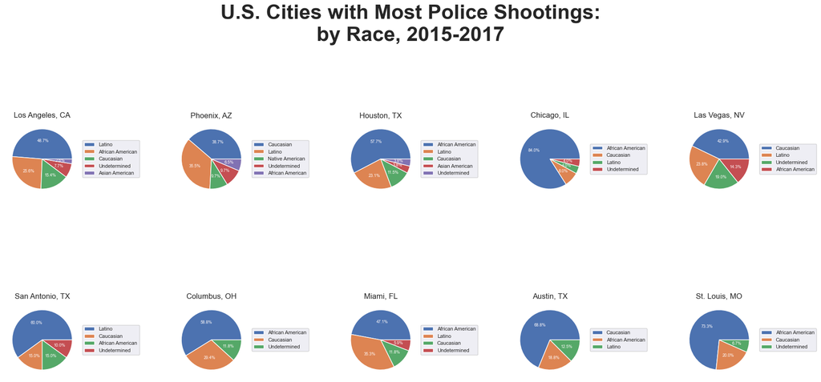

```python
# fig = plt.figure(figsize=(18, 10), dpi=1600)  # High DPI for saving image
fig = plt.figure(figsize=(18, 10))

cols = 2
rows = 5
ind = 0

for col in range(cols):
    for row in range(rows):
        city = city_tuples[ind]
        ax1 = plt.subplot2grid((cols, rows), (col, row))
        # Plot each sub-pie chart and customize text:
        plt.pie(city[0],
                autopct='%1.1f%%',
                textprops={'color': 'snow', 'size': 6.5})
        plt.title(city[1])
        # Add legend and customize location/text:
        ax1.legend(labels=city[0].index,
                   loc='center left',
                   bbox_to_anchor=(1, 0.5),
                   prop={'size': 8})
        ind += 1

title = "U.S. Cities with Most Police Shootings:"
title += "\nby Race, 2015-2017"

plt.suptitle(title, size=32, weight='bold')

# Optimize plot/legend layout:
plt.tight_layout(w_pad=4.5)  # (Causes padding issue beneath title...)

plt.show()
```

#### *Analysis:*

**These conclusions do not account for portions *Undetermined*:**

- Columbus had killings of only *Caucasians* and *African Americans*.
- *Austin* had killings of only *Caucasians*, *African Americans* and *Latinos*.
- The most killed in Los Angeles and *San Antonio* were *Latino*.
- Caucasians were the highest number killed in *Austin*, *Las Vegas* and *Phoenix*.
- African Americans were the most killed in *Houston*, *Chicago*, *Columbus*, *Miami* and *St. Louis*.

# *Create a Choropleth Map of Police Killings by US State*

Which states are the most dangerous? Compare your map with your previous chart. Are these the same states with high degrees of poverty?

```python
df_state = df_fatalities.groupby('state').size().reset_index(name='Number Killed')
```

```python
df_state.sort_values(by='Number Killed', ascending=False, inplace=True)
```

```python
df_state.reset_index(inplace=True, drop=True)
```

```python
# Try different color scales:
color_scales = ['aggrnyl', 'agsunset', 'blackbody', 'bluered', 'blues', 'blugrn',
                'bluyl', 'brwnyl', 'bugn', 'bupu', 'burg', 'burgyl', 'cividis',
                'darkmint', 'electric', 'emrld', 'gnbu', 'greens', 'greys', 'hot',
                'inferno', 'jet', 'magenta', 'magma', 'mint', 'orrd', 'oranges', 'oryel',
                'peach', 'pinkyl', 'plasma', 'plotly3', 'pubu', 'pubugn', 'purd', 'purp',
                'purples', 'purpor', 'rainbow', 'rdbu', 'rdpu', 'redor', 'reds', 'sunset',
                'sunsetdark  teal', 'tealgrn', 'turbo', 'viridis', 'ylgn', 'ylgnbu',
                'ylorbr', 'ylorrd', 'algae', 'amp', 'deep', 'dense', 'gray', 'haline',
                'ice', 'matter', 'solar', 'speed', 'tempo', 'thermal', 'turbid',
                'armyrose', 'brbg', 'earth', 'fall', 'geyser', 'prgn', 'piyg', 'picnic',
                'portland', 'puor', 'rdgy', 'rdylbu', 'rdylgn', 'spectral', 'tealrose',
                'temps', 'tropic', 'balance', 'curl', 'delta', 'oxy', 'edge', 'hsv',
                'icefire', 'phase', 'twilight', 'mrybm', 'mygbm']
```

```python
fig = px.choropleth(
    df_state,
    locations='state',
    color='Number Killed',
    locationmode='USA-states',
    scope='usa',
    color_continuous_scale='aggrnyl',
    width=1000,
    height=650,
)

title = f"Choropleth Map: U.S. Police Killings 2015-2017"

fig.update_layout(
    title_text=title,
    title_font_size=28,
    title_font_family='Courier New',
    title_xref='paper',
)

fig.show()
```

#### *Analysis:*

- California, Texas and Florida have the most killings.
- The Upper Midwest and Northeast have the fewest.

```python
df_pov_state['Geographic Area'].values
```

```
array(['AZ', 'MS', 'NM', 'GA', 'AR', 'WV', 'LA', 'SC', 'AK', 'AL', 'OK',
       'TX', 'MO', 'KY', 'TN', 'NC', 'ID', 'MT', 'SD', 'CA', 'MI', 'DC',
       'FL', 'OR', 'ME', 'IN', 'WA', 'NV', 'KS', 'VA', 'OH', 'CO', 'VT',
       'ND', 'IL', 'MN', 'NE', 'NH', 'HI', 'WY', 'WI', 'PA', 'IA', 'UT',
       'DE', 'NY', 'MD', 'RI', 'MA', 'CT', 'NJ'], dtype=object)
```

- California doesn't have the most poverty, so that doesn't exactly match up with the killings by state statistic -- but it does have a very high population, so we should consider that, and perphaps bring that statistic into our analysis in the next refactor...
- Massachusetts and Connecticut seem to abide by the cross-analysis of low-poverty and fewer number of shootings.

# *Number of Police Killings Over Time*

Analyse the Number of Police Killings over Time. Is there a trend in the data?

#### *Clean/transform data:*

```python
# Make a copy in case of mistakes:
df_fatalities_months = df_fatalities.filter(['date'], axis=1)
df_fatalities_days = df_fatalities.filter(['date'], axis=1)
```

```python
# Convert to datetime objects:
df_fatalities_months['date'] = pd.to_datetime(df_fatalities_months['date'], format='%d/%m/%y')
df_fatalities_days['date'] = pd.to_datetime(df_fatalities_months['date'], format='%d/%m/%y')
```

```python
# Make the data for `df_fatalities_months` scale on months, not days:
df_fatalities_months['date'] = df_fatalities_months['date'].dt.strftime('%m/%y')
```

```python
# Make DF grouped by date (months) and their counts for ease/clarity of plotting:
df_fatalities_months = df_fatalities_months.groupby('date').size().reset_index(name='count')

# Make DF grouped by date (days):
df_fatalities_days = df_fatalities_days.groupby('date').size().reset_index(name='count')
```

We now have a DataFrame based on months and another on days.

We can look at plots for each and compare. The months should be better for 'at-a-glance', the days for a more in-depth analysis.

#### *Plot:*

```python
# Import and define matplotlib.dates helpers:
import matplotlib.dates as mdates

years = mdates.YearLocator()
year_fmt = mdates.DateFormatter('%Y')

months = mdates.MonthLocator()
month_fmt = mdates.DateFormatter('%b')
```

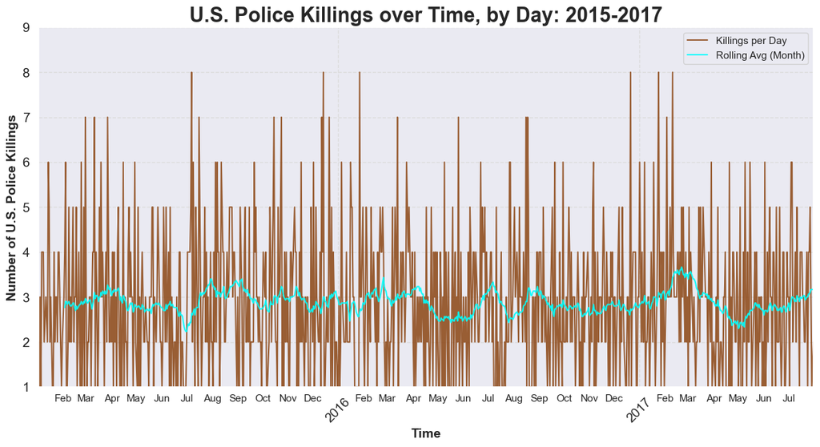

```python
# Plot months:
fig, ax = plt.subplots(figsize=(15, 7))

title = "U.S. Police Killings over Time, by Day: 2015-2017"

ax.set_title(title,
             fontsize=22,
             weight='bold')

ax.tick_params(axis='both', labelsize=10)

ax.set_xlabel('Time', fontsize=14, weight='bold')
ax.set_ylabel('Number of U.S. Police Killings', fontsize=14, weight='bold')

plt.xticks(fontsize=14, rotation=45)
plt.yticks(fontsize=14)

ax.xaxis.set_major_locator(years)
ax.xaxis.set_major_formatter(year_fmt)
ax.xaxis.set_minor_locator(months)
ax.xaxis.set_minor_formatter(month_fmt)

all_dates = df_fatalities_days['date']
all_counts = df_fatalities_days['count']

ax.set_xlim([all_dates.min(), all_dates.max()])
ax.set_ylim([all_counts.min(), all_counts.max() + 1])

ax.grid(color='gainsboro', linestyle='--')

ax.plot(
    all_dates,
    all_counts,
    label="Killings per Day",
    color='saddlebrown',
    alpha=.85,
)

# Optional rolling windows:
# rolling_2_days = df_fatalities_days['count'].rolling(window=2).mean()
# ax.plot(
#     all_dates,
#     rolling_2_days,
#     label="Killings per 2-Days",
#     color='black',
#     alpha=.85,
# )

# rolling_week = df_fatalities_days['count'].rolling(window=7).mean()
# ax.plot(
#     all_dates,
#     rolling_week,
#     label=f"Killings per Week",
#     color='crimson',
#     alpha=.9,
# )

rolling_month = df_fatalities_days['count'].rolling(window=30).mean()
ax.plot(
    all_dates,
    rolling_month,
    label=f"Rolling Avg (Month)",
    color='cyan',
    alpha=.9,
)

plt.legend()
plt.show()
```

#### *Analysis:*

We should isolate each year to get more specific analysis -- I'll do this in the next draft.

# *Epilogue*

Now that you have analysed the data yourself, read [The Washington Post's analysis here](https://www.washingtonpost.com/graphics/investigations/police-shootings-database/).

#### *Analysis and Conclusion:*

At the outset I scoured the internet searching for updated data -- upon looking at this link from the Washington Post more clearly, I see they have the updated data there!

I'll factor this in during my next pass over this project.

It pays to pay attention!!

The Washington Post makes it clear that African Americans are killed at a disproportionate rate.

In my next refactor, I need to do a better analysis of population by race and killings by race.

Either I mis-read the instructions for this project/assignment or there wasn't enough emphasis placed on comparing these important two factors.

In any case, that's on me, since this is a project which allows freedom in how I analyze, so I will do that, along with updating the dataset, on my next pass.

For now I'm satisfied with my ability to answer this projects challenges, and feel like my handle on Pandas, Matplotlib, Seaborn and Plotly has vastly improved.

In conclusion, my technical abilities seem good for this project, but I need a bit more work on the creative/intellectual side of how to analyze and compare the data points, and should feel more free to go outside the box when it comes to finding ways to look at the data that might benefit the analysis.

A lot that required research/looking up has now become a lot more natural.

I'm almost finished with this course.

This is the final day's project, but I waited to finish the day where we add a 'store' to our website -- this will involve adding a database and login functionality for users.

I purposefully left this for last, since it will be very challenging, meaningful and a continuing project for me after this course is finished.